# Exploring the Relationship Between Student Habits and Academic Success

## 1. Import Libraries

```r
library(dplyr)
library(ggplot2)
library(e1071)
library(corrplot)
library(caret)
library(visdat)
library(car)
library(PRROC)
library(rpart)
library(rpart.plot)
library(pROC)
library(randomForest)
library(reshape2)
library(scales)
```

## 2. Load Data

```r
# Read the dataset from the working directory
stu_df <- read.csv("student_habits_performance.csv")

# Inspect variable names, types, and a preview of values
str(stu_df)
```

```
## 'data.frame':    1000 obs. of  16 variables:
##  $ student_id                   : chr  "S1000" "S1001" "S1002" "S1003" ...
##  $ age                          : int  23 20 21 23 19 24 21 21 23 18 ...
##  $ gender                       : chr  "Female" "Female" "Male" "Female" ...
##  $ study_hours_per_day          : num  0 6.9 1.4 1 5 7.2 5.6 4.3 4.4 4.8 ...
##  $ social_media_hours           : num  1.2 2.8 3.1 3.9 4.4 1.3 1.5 1 2.2 3.1 ...
##  $ netflix_hours                : num  1.1 2.3 1.3 1 0.5 0 1.4 2 1.7 1.3 ...
##  $ part_time_job                : chr  "No" "No" "No" "No" ...
##  $ attendance_percentage        : num  85 97.3 94.8 71 90.9 82.9 85.8 77.7 100 95.4 ...
##  $ sleep_hours                  : num  8 4.6 8 9.2 4.9 7.4 6.5 4.6 7.1 7.5 ...
##  $ diet_quality                 : chr  "Fair" "Good" "Poor" "Poor" ...
##  $ exercise_frequency           : int  6 6 1 4 3 1 2 0 3 5 ...
##  $ parental_education_level     : chr  "Master" "High School" "High School" "Master" ...
##  $ internet_quality             : chr  "Average" "Average" "Poor" "Good" ...
##  $ mental_health_rating         : int  8 8 1 1 1 4 4 8 1 10 ...
##  $ extracurricular_participation: chr  "Yes" "No" "No" "Yes" ...
##  $ exam_score                   : num  56.2 100 34.3 26.8 66.4 100 89.8 72.6 78.9 100 ...
```

## 3. Data Exploration

```r
# Summary statistics for all variables
summary(stu_df)
```

```
##   student_id             age           gender          study_hours_per_day
##  Length:1000        Min.   :17.00   Length:1000        Min.   :0.00
##  Class :character   1st Qu.:18.75   Class :character   1st Qu.:2.60
##  Mode  :character   Median :20.00   Mode  :character   Median :3.50
##                     Mean   :20.50                      Mean   :3.55
##                     3rd Qu.:23.00                      3rd Qu.:4.50
##                     Max.   :24.00                      Max.   :8.30
##  social_media_hours netflix_hours   part_time_job      attendance_percentage
##  Min.   :0.000      Min.   :0.000   Length:1000        Min.   : 56.00
##  1st Qu.:1.700      1st Qu.:1.000   Class :character   1st Qu.: 78.00
##  Median :2.500      Median :1.800   Mode  :character   Median : 84.40
##  Mean   :2.506      Mean   :1.820                      Mean   : 84.13
##  3rd Qu.:3.300      3rd Qu.:2.525                      3rd Qu.: 91.03
##  Max.   :7.200      Max.   :5.400                      Max.   :100.00
##   sleep_hours    diet_quality       exercise_frequency parental_education_level
##  Min.   : 3.20   Length:1000        Min.   :0.000      Length:1000
##  1st Qu.: 5.60   Class :character   1st Qu.:1.000      Class :character
##  Median : 6.50   Mode  :character   Median :3.000      Mode  :character
##  Mean   : 6.47                      Mean   :3.042
##  3rd Qu.: 7.30                      3rd Qu.:5.000
##  Max.   :10.00                      Max.   :6.000
##  internet_quality   mental_health_rating extracurricular_participation
##  Length:1000        Min.   : 1.000       Length:1000
##  Class :character   1st Qu.: 3.000       Class :character
##  Mode  :character   Median : 5.000       Mode  :character
##                     Mean   : 5.438
##                     3rd Qu.: 8.000
##                     Max.   :10.000
##    exam_score
##  Min.   : 18.40
##  1st Qu.: 58.48
##  Median : 70.50
##  Mean   : 69.60
##  3rd Qu.: 81.33
##  Max.   :100.00
```

The dataset contains 1,000 students aged 17-24. Students study an average of 3.5 hours per day, spend ~2.5 hours on social media, and sleep ~6.5 hours. Most students do not hold a part-time job. Exam scores range from 18 to 100 with a mean of ~69.6.

```r
# Preview the first 6 rows
head(stu_df)
```

```
##   student_id age gender study_hours_per_day social_media_hours netflix_hours
## 1      S1000  23 Female                 0.0                1.2           1.1
## 2      S1001  20 Female                 6.9                2.8           2.3
## 3      S1002  21   Male                 1.4                3.1           1.3
## 4      S1003  23 Female                 1.0                3.9           1.0
## 5      S1004  19 Female                 5.0                4.4           0.5
## 6      S1005  24   Male                 7.2                1.3           0.0
##   part_time_job attendance_percentage sleep_hours diet_quality
## 1            No                  85.0         8.0         Fair
## 2            No                  97.3         4.6         Good
## 3            No                  94.8         8.0         Poor
## 4            No                  71.0         9.2         Poor
## 5            No                  90.9         4.9         Fair
## 6            No                  82.9         7.4         Fair
##   exercise_frequency parental_education_level internet_quality
## 1                  6                   Master          Average
## 2                  6              High School          Average
## 3                  1              High School             Poor
## 4                  4                   Master             Good
## 5                  3                   Master             Good
## 6                  1                   Master          Average
##   mental_health_rating extracurricular_participation exam_score
## 1                    8                           Yes       56.2
## 2                    8                            No      100.0
## 3                    1                            No       34.3
## 4                    1                           Yes       26.8
## 5                    1                            No       66.4
## 6                    4                            No      100.0
```

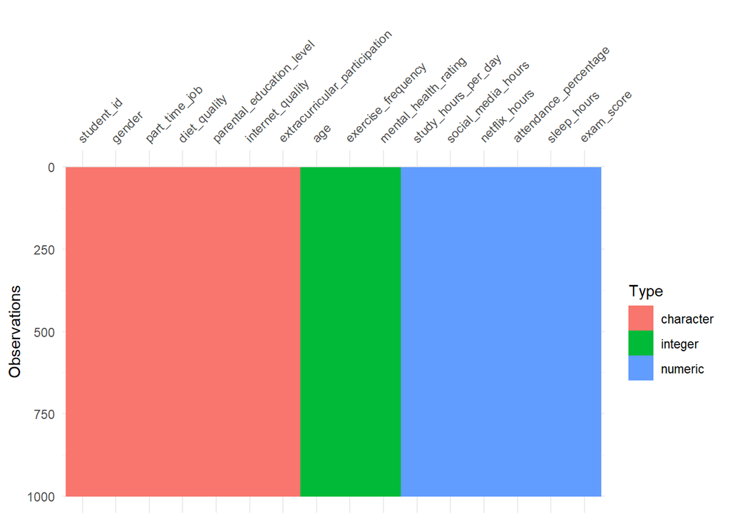

```r
vis_dat(stu_df)
```

```r
anyNA(stu_df)
```

```
## [1] FALSE
```

No missing values were found. The dataset is clean and ready for preprocessing.

## 4. Data Preprocessing

### 4.1 Convert Categorical Variables to Factor

```r
stu_df$gender                        <- as.factor(stu_df$gender)
stu_df$part_time_job                 <- as.factor(stu_df$part_time_job)
stu_df$diet_quality                  <- as.factor(stu_df$diet_quality)
stu_df$parental_education_level      <- as.factor(stu_df$parental_education_level)
stu_df$internet_quality              <- as.factor(stu_df$internet_quality)
stu_df$extracurricular_participation <- as.factor(stu_df$extracurricular_participation)

str(stu_df)
```

```
## 'data.frame':    1000 obs. of  16 variables:
##  $ student_id                   : chr  "S1000" "S1001" "S1002" "S1003" ...
##  $ age                          : int  23 20 21 23 19 24 21 21 23 18 ...
##  $ gender                       : Factor w/ 3 levels "Female","Male",..: 1 1 2 1 1 2 1 1 1 1 ...
##  $ study_hours_per_day          : num  0 6.9 1.4 1 5 7.2 5.6 4.3 4.4 4.8 ...
##  $ social_media_hours           : num  1.2 2.8 3.1 3.9 4.4 1.3 1.5 1 2.2 3.1 ...
##  $ netflix_hours                : num  1.1 2.3 1.3 1 0.5 0 1.4 2 1.7 1.3 ...
##  $ part_time_job                : Factor w/ 2 levels "No","Yes": 1 1 1 1 1 1 2 2 1 1 ...
##  $ attendance_percentage        : num  85 97.3 94.8 71 90.9 82.9 85.8 77.7 100 95.4 ...
##  $ sleep_hours                  : num  8 4.6 8 9.2 4.9 7.4 6.5 4.6 7.1 7.5 ...
##  $ diet_quality                 : Factor w/ 3 levels "Fair","Good",..: 1 2 3 3 1 1 2 1 2 2 ...
##  $ exercise_frequency           : int  6 6 1 4 3 1 2 0 3 5 ...
##  $ parental_education_level     : Factor w/ 4 levels "Bachelor","High School",..: 3 2 2 3 3 3 3 1 1 1 ...
##  $ internet_quality             : Factor w/ 3 levels "Average","Good",..: 1 1 3 2 2 1 3 1 2 2 ...
##  $ mental_health_rating         : int  8 8 1 1 1 4 4 8 1 10 ...
##  $ extracurricular_participation: Factor w/ 2 levels "No","Yes": 2 1 1 2 1 1 1 1 1 2 ...
##  $ exam_score                   : num  56.2 100 34.3 26.8 66.4 100 89.8 72.6 78.9 100 ...
```

### 4.2 Remove student_id

```r
# student_id is just a row identifier with no predictive information
stu_df <- stu_df |> dplyr::select(-student_id)
```

### 4.3 Outlier Check

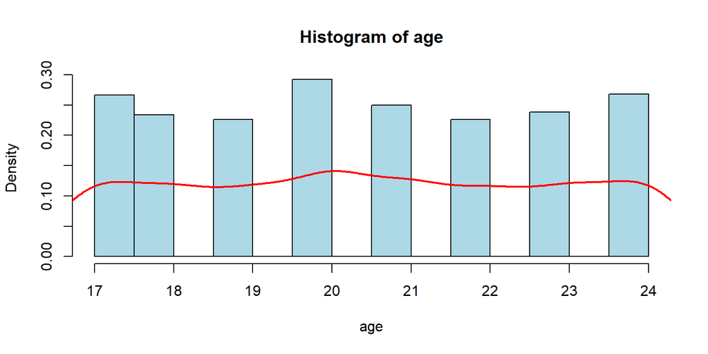

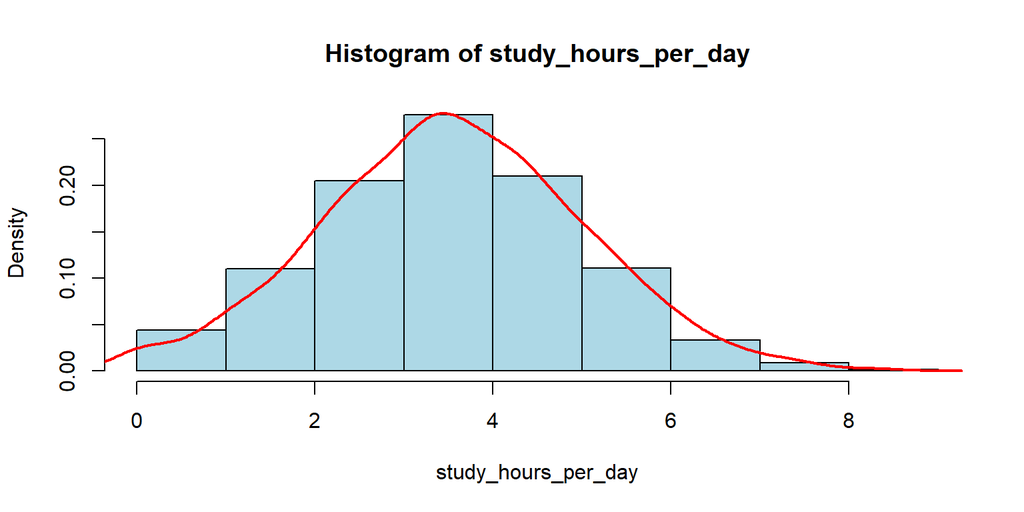

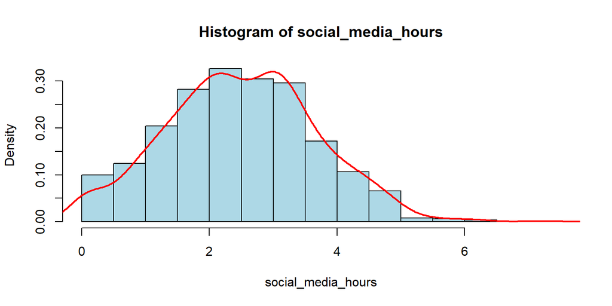

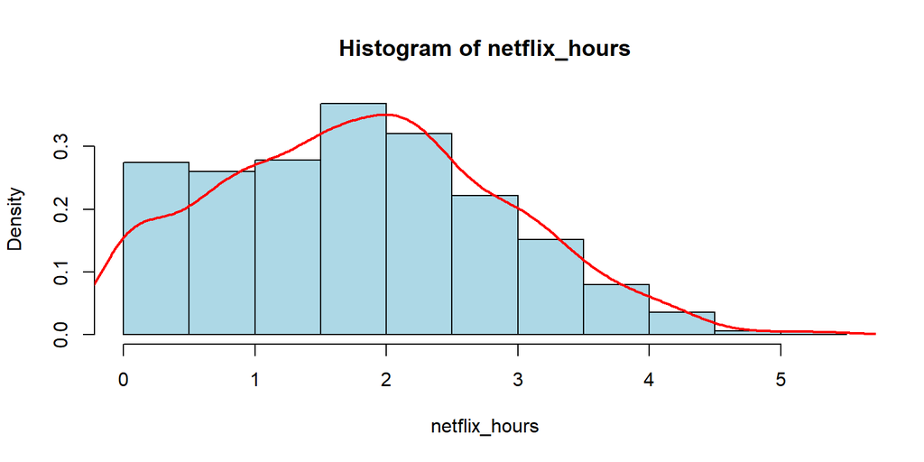

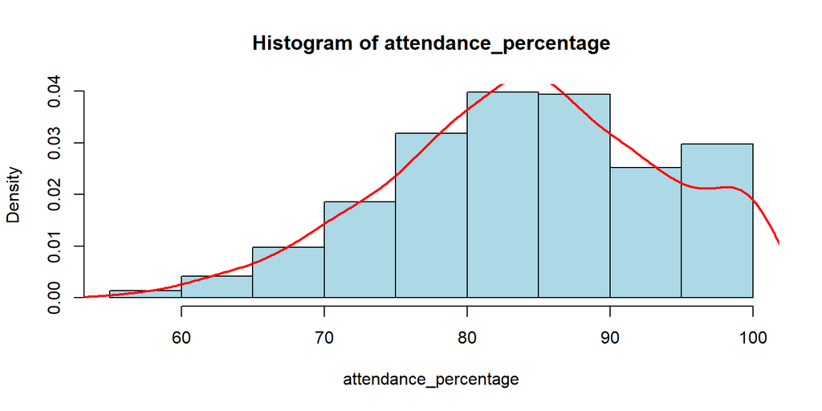

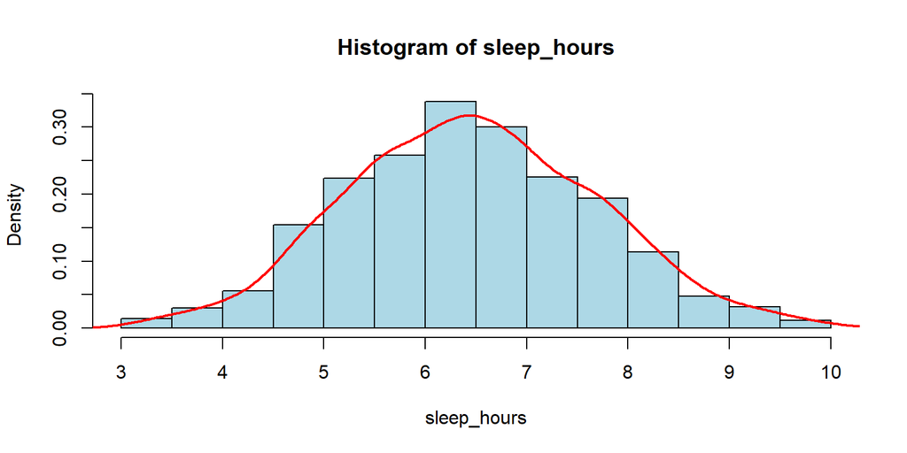

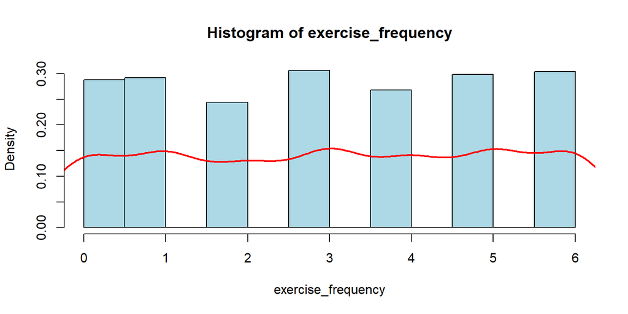

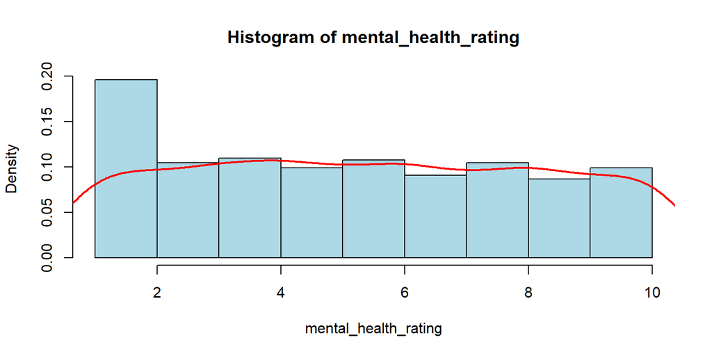

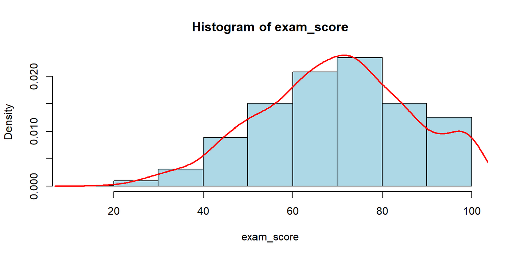

```r
# Loop through every numeric column and plot a histogram with a density overlay
# This lets us visually detect skewness and extreme outliers
for (col in names(stu_df)) {
  if (is.numeric(stu_df[[col]])) {
    hist(stu_df[[col]],
         main        = paste("Histogram of", col),
         xlab        = col,
         col         = "lightblue",
         border      = "black",
         probability = TRUE)
    # Red density curve shows the overall distribution shape
    lines(density(stu_df[[col]], na.rm = TRUE), col = "red", lwd = 2)
  }
}
```

Distributions show mild skewness for some variables, but no extreme outliers require removal. All observations are retained.

### 4.4 Visualize Categorical Variables

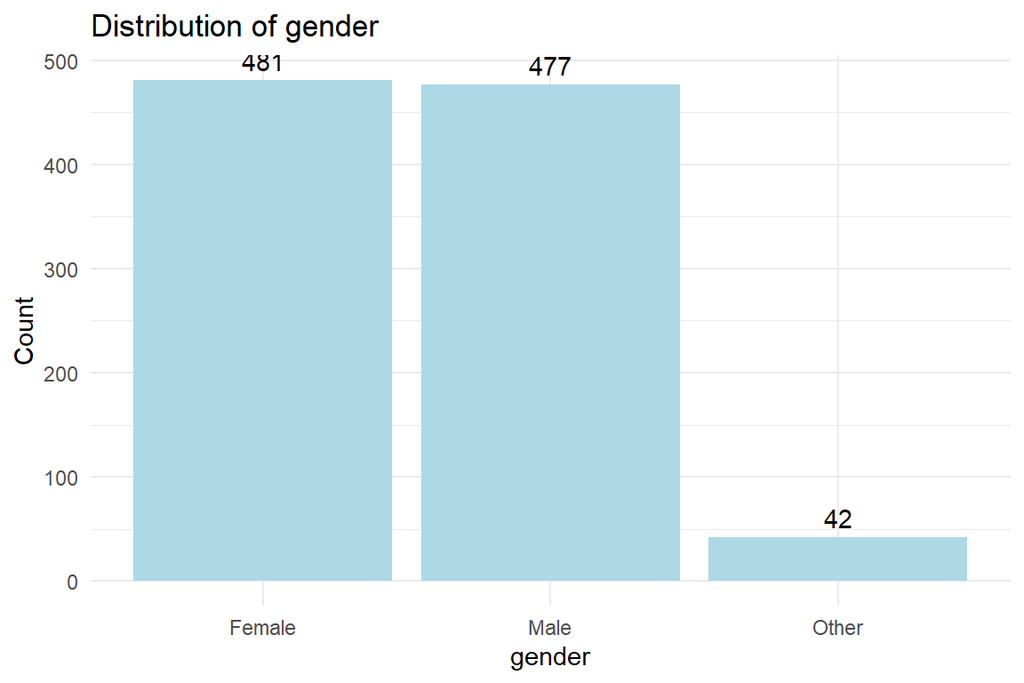

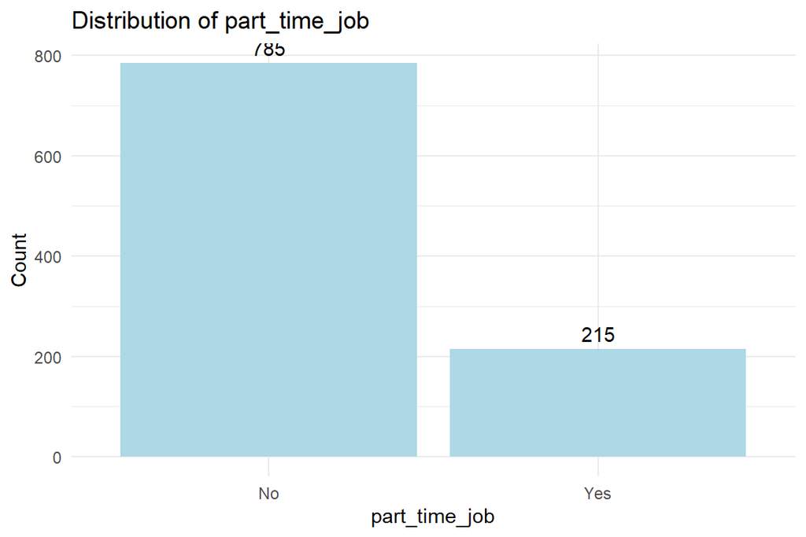

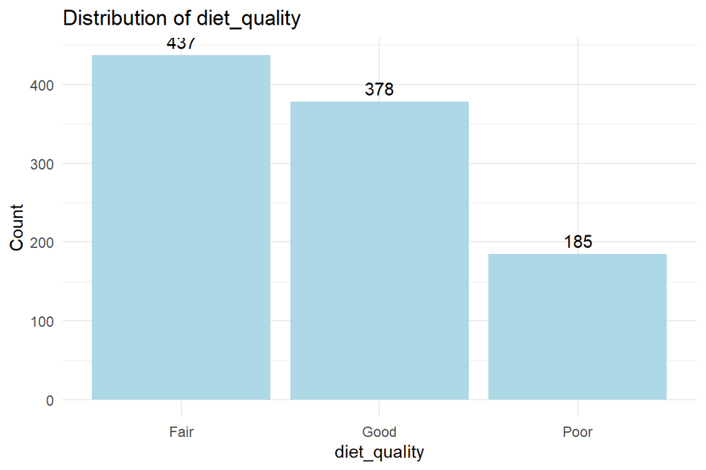

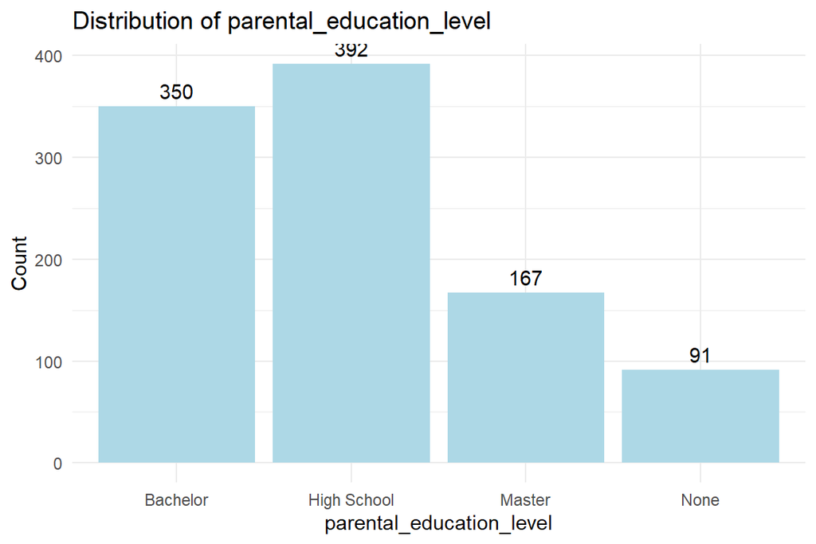

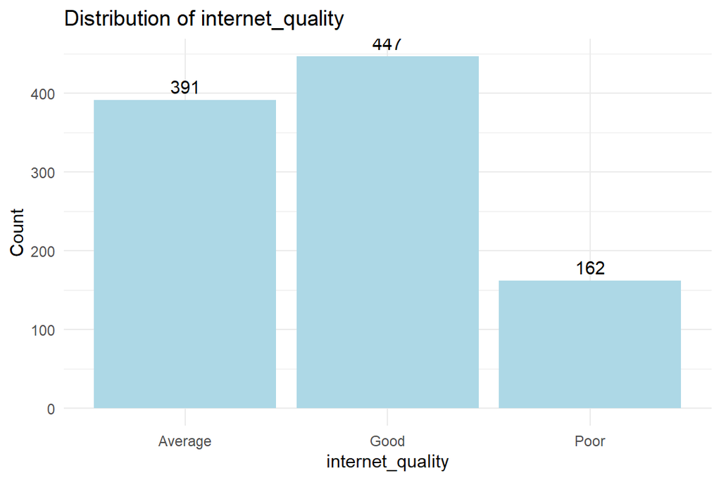

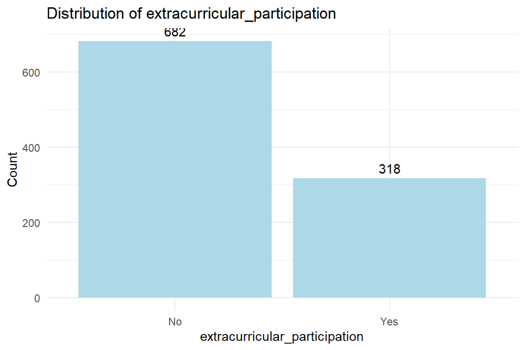

```r
for (col in colnames(stu_df)) {
  if (is.factor(stu_df[[col]])) {
    print(
      ggplot(stu_df, aes(x = .data[[col]])) +
        geom_bar(fill = "lightblue") +
        geom_text(stat  = "count",
                  aes(label = after_stat(count)),
                  vjust = -0.5,
                  color = "black") +
        labs(title = paste("Distribution of", col), x = col, y = "Count") +
        theme_minimal()
    )
  }
}
```

### 4.5 Correlation Matrix

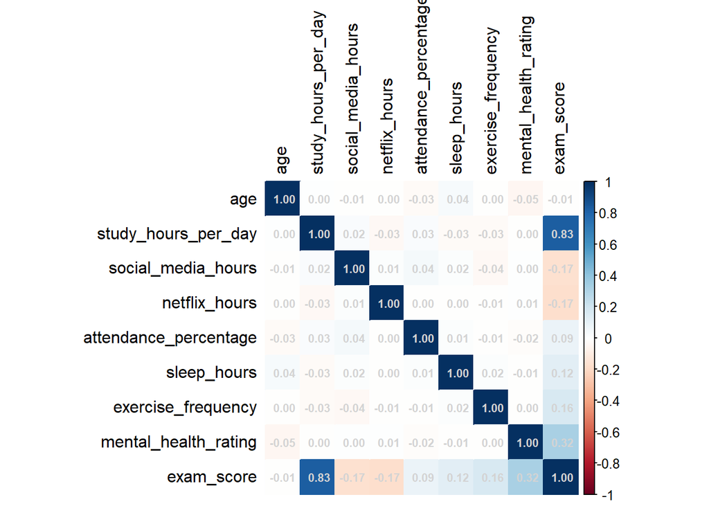

```r
# Compute Pearson correlation between all numeric predictors.
cor_matrix <- cor(stu_df[, sapply(stu_df, is.numeric)])

corrplot(cor_matrix,
         method      = "color",
         addCoef.col = "lightgrey",
         tl.col      = "black",
         number.cex  = 0.7)
```

`study_hours_per_day` shows the strongest correlation with `exam_score`. Note that `exam_score` will be removed before modeling — its correlations here are shown for exploratory context only.

### 4.6 Create Pass/Fail Outcome Variable

```r
# Students scoring >= 70 are labelled "pass", below 70 are "fail"
threshold        <- 70
stu_df$pass_fail <- ifelse(stu_df$exam_score >= threshold, "pass", "fail")
stu_df$pass_fail <- as.factor(stu_df$pass_fail)

str(stu_df)
```

```
## 'data.frame':    1000 obs. of  16 variables:
##  $ age                          : int  23 20 21 23 19 24 21 21 23 18 ...
##  $ gender                       : Factor w/ 3 levels "Female","Male",..: 1 1 2 1 1 2 1 1 1 1 ...
##  $ study_hours_per_day          : num  0 6.9 1.4 1 5 7.2 5.6 4.3 4.4 4.8 ...
##  $ social_media_hours           : num  1.2 2.8 3.1 3.9 4.4 1.3 1.5 1 2.2 3.1 ...
##  $ netflix_hours                : num  1.1 2.3 1.3 1 0.5 0 1.4 2 1.7 1.3 ...
##  $ part_time_job                : Factor w/ 2 levels "No","Yes": 1 1 1 1 1 1 2 2 1 1 ...
##  $ attendance_percentage        : num  85 97.3 94.8 71 90.9 82.9 85.8 77.7 100 95.4 ...
##  $ sleep_hours                  : num  8 4.6 8 9.2 4.9 7.4 6.5 4.6 7.1 7.5 ...
##  $ diet_quality                 : Factor w/ 3 levels "Fair","Good",..: 1 2 3 3 1 1 2 1 2 2 ...
##  $ exercise_frequency           : int  6 6 1 4 3 1 2 0 3 5 ...
##  $ parental_education_level     : Factor w/ 4 levels "Bachelor","High School",..: 3 2 2 3 3 3 3 1 1 1 ...
##  $ internet_quality             : Factor w/ 3 levels "Average","Good",..: 1 1 3 2 2 1 3 1 2 2 ...
##  $ mental_health_rating         : int  8 8 1 1 1 4 4 8 1 10 ...
##  $ extracurricular_participation: Factor w/ 2 levels "No","Yes": 2 1 1 2 1 1 1 1 1 2 ...
##  $ exam_score                   : num  56.2 100 34.3 26.8 66.4 100 89.8 72.6 78.9 100 ...
##  $ pass_fail                    : Factor w/ 2 levels "fail","pass": 1 2 1 1 1 2 2 2 2 2 ...
```

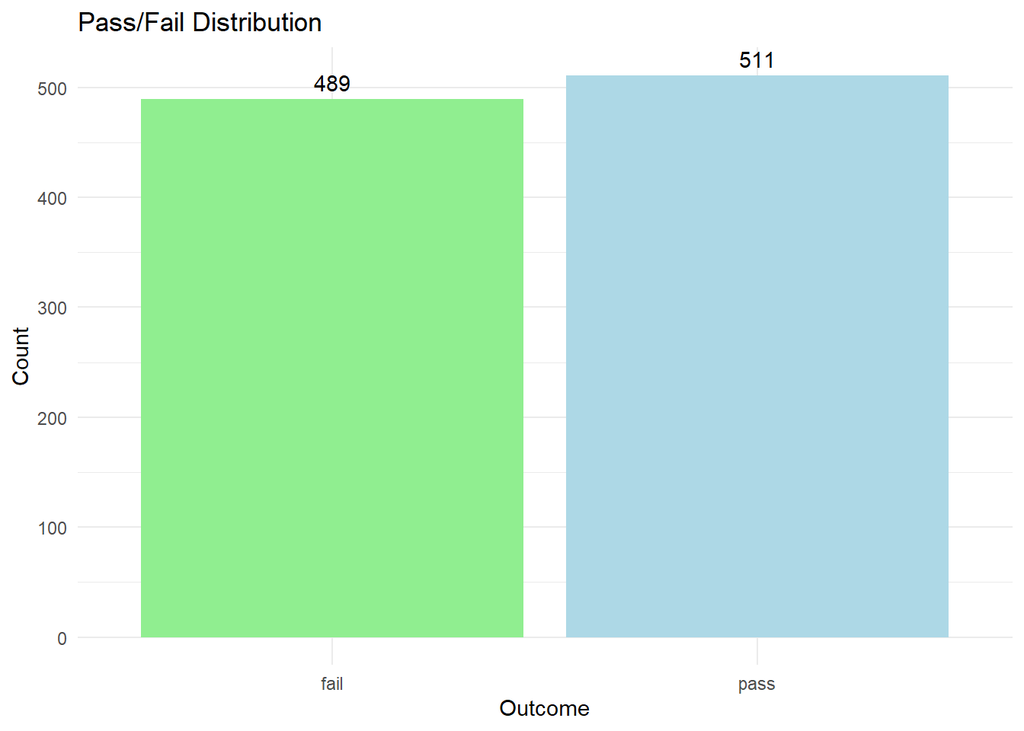

```r
# Check the class balance
stu_df |>
  ggplot(aes(x = pass_fail, fill = pass_fail)) +
  geom_bar() +
  scale_fill_manual(values = c("fail" = "lightgreen", "pass" = "lightblue")) +
  geom_text(stat = "count", aes(label = after_stat(count)), vjust = -0.5) +
  labs(title = "Pass/Fail Distribution", x = "Outcome", y = "Count") +
  theme_minimal() +
  theme(legend.position = "none")
```

The dataset is well-balanced: 511 pass and 489 fail. This is good for classification modeling as neither class dominates.

## 5. Exploratory Data Analysis (EDA)

### EDA Q1 — How do study habits influence the likelihood of passing or failing?

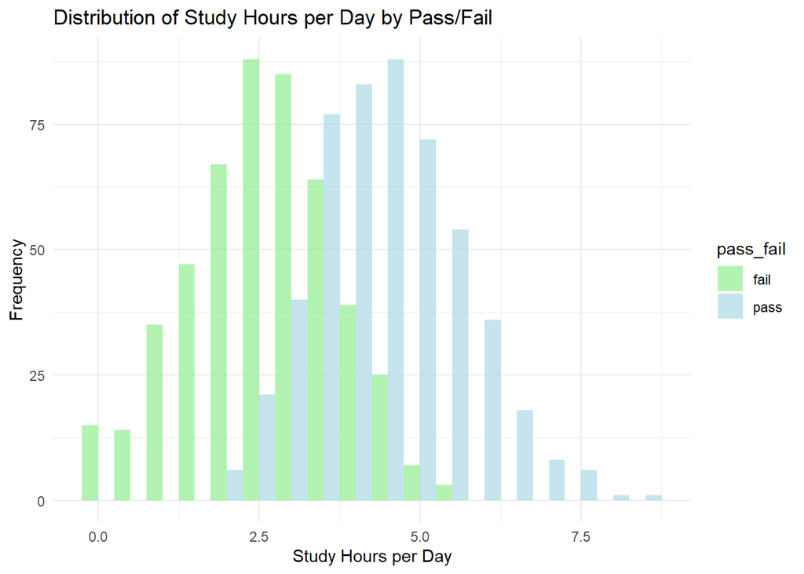

```r
ggplot(stu_df, aes(x = study_hours_per_day, fill = pass_fail)) +
  geom_histogram(binwidth = 0.5, alpha = 0.7, position = "dodge") +
  scale_fill_manual(values = c("fail" = "lightgreen", "pass" = "lightblue")) +
  labs(title = "Distribution of Study Hours per Day by Pass/Fail",
       x     = "Study Hours per Day",
       y     = "Frequency") +
  theme_minimal()
```

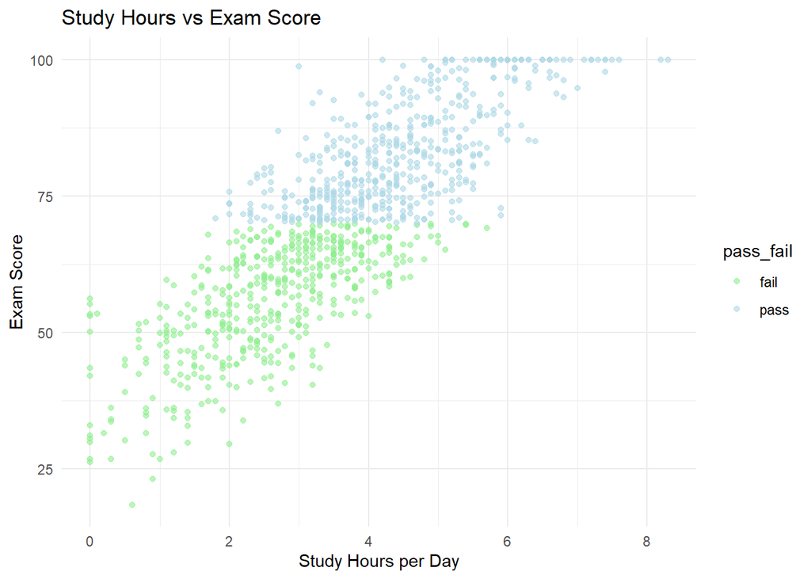

```r
ggplot(stu_df, aes(x = study_hours_per_day, y = exam_score, color = pass_fail)) +
  geom_point(alpha = 0.6) +
  scale_color_manual(values = c("fail" = "lightgreen", "pass" = "lightblue")) +
  labs(title = "Study Hours vs Exam Score",
       x     = "Study Hours per Day",
       y     = "Exam Score") +
  theme_minimal()
```

Students who study more tend to pass. Most passing students study 3+ hours per day while failing students cluster below 3 hours. Study hours is expected to be the strongest predictor in our models.

### EDA Q2 — Does mental health affect academic success?

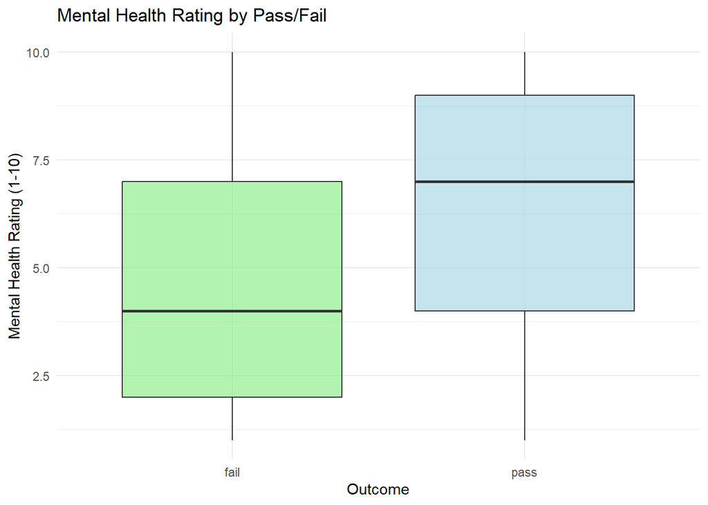

```r
ggplot(stu_df, aes(x = pass_fail, y = mental_health_rating, fill = pass_fail)) +
  geom_boxplot(alpha = 0.7) +
  scale_fill_manual(values = c("fail" = "lightgreen", "pass" = "lightblue")) +
  labs(title = "Mental Health Rating by Pass/Fail",
       x     = "Outcome",
       y     = "Mental Health Rating (1-10)") +
  theme_minimal() +
  theme(legend.position = "none")
```

Passing students have a noticeably higher median mental health rating (7) compared to failing students (4). Mental well being plays a meaningful role in academic outcomes.

### EDA Q3 — How do part-time jobs impact academic performance?

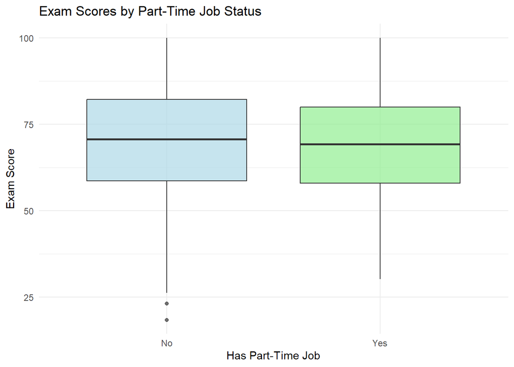

```r
ggplot(stu_df, aes(x = part_time_job, y = exam_score, fill = part_time_job)) +
  geom_boxplot(alpha = 0.7) +
  scale_fill_manual(values = c("No" = "lightblue", "Yes" = "lightgreen")) +
  labs(title = "Exam Scores by Part-Time Job Status",
       x     = "Has Part-Time Job",
       y     = "Exam Score") +
  theme_minimal() +
  theme(legend.position = "none")
```

The medians are very close (~70.6 no job vs ~69.2 with job), suggesting part-time work has a smaller effect on academic performance than commonly assumed.

### EDA Q4 — How does attendance relate to exam performance?

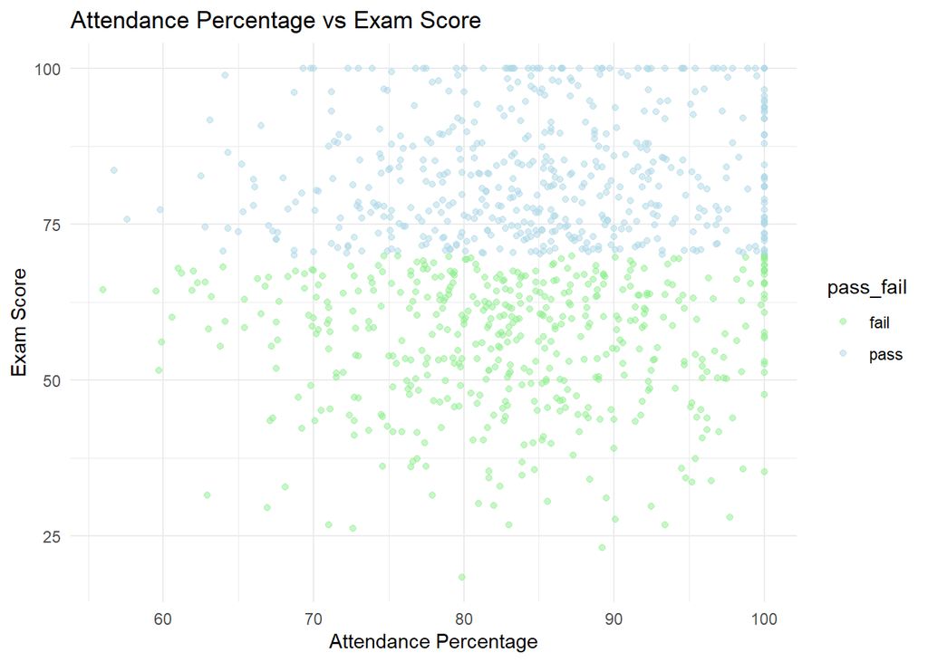

```r
ggplot(stu_df, aes(x = attendance_percentage, y = exam_score, color = pass_fail)) +
  geom_point(alpha = 0.5) +
  scale_color_manual(values = c("fail" = "lightgreen", "pass" = "lightblue")) +
  labs(title = "Attendance Percentage vs Exam Score",
       x     = "Attendance Percentage",
       y     = "Exam Score") +
  theme_minimal()
```

Unlike study hours, attendance shows a weaker and more scattered relationship with exam scores. Both passing and failing students span the full attendance range, confirming that showing up alone is not enough — study habits matter more.

## 6. Prepare Data for Modeling

### 6.1 Remove exam_score

```r
stu_df <- stu_df |> dplyr::select(-exam_score)
```

### 6.2 Train / Test Split

```r
# 70% training, 30% test
set.seed(28)
train_index <- createDataPartition(stu_df$pass_fail, p = 0.7, list = FALSE)
stu_train   <- stu_df[train_index, ]
stu_test    <- stu_df[-train_index, ]

cat("Training set size:", nrow(stu_train), "\n")
```

```
## Training set size: 701
```

```r
cat("Test set size:    ", nrow(stu_test),  "\n")
```

```
## Test set size:     299
```

## 7. Helper Functions for Evaluation Plots

```r
# ------------------------------------------------------------------
# plot_confusion_heatmap()
# ------------------------------------------------------------------
plot_confusion_heatmap <- function(pred_classes, true_classes, model_name) {
  cm     <- confusionMatrix(pred_classes, true_classes)
  cm_tbl <- as.data.frame(cm$table)

  ggplot(cm_tbl, aes(x = Reference, y = Prediction, fill = Freq)) +
    geom_tile(color = "white") +
    geom_text(aes(label = Freq), size = 6, fontface = "bold") +
    scale_fill_gradient(low = "white", high = "steelblue") +
    labs(title = paste("Confusion Matrix Heatmap -", model_name),
         x = "Actual", y = "Predicted", fill = "Count") +
    theme_minimal(base_size = 13)
}

# ------------------------------------------------------------------
# plot_actual_vs_predicted()
# ------------------------------------------------------------------
plot_actual_vs_predicted <- function(pred_classes, true_classes, model_name) {
  df <- data.frame(
    Actual    = true_classes,
    Predicted = pred_classes,
    Correct   = ifelse(pred_classes == true_classes, "Correct", "Incorrect")
  )

  ggplot(df, aes(x = Actual, y = Predicted, color = Correct)) +
    geom_jitter(width = 0.2, height = 0.2, alpha = 0.6, size = 2) +
    scale_color_manual(values = c("Correct" = "steelblue", "Incorrect" = "tomato")) +
    labs(title = paste("Actual vs Predicted -", model_name),
         x = "Actual Class", y = "Predicted Class", color = "Result") +
    theme_minimal(base_size = 13)
}

# ------------------------------------------------------------------
# plot_prob_distribution()
# ------------------------------------------------------------------
plot_prob_distribution <- function(probs, true_classes, model_name) {
  data.frame(prob = probs, actual = true_classes) |>
    ggplot(aes(x = prob, fill = actual)) +
    geom_density(alpha = 0.5) +
    scale_fill_manual(values = c("fail" = "lightgreen", "pass" = "lightblue")) +
    geom_vline(xintercept = 0.5, linetype = "dashed", color = "red") +
    labs(title = paste("Predicted Probability Distribution -", model_name),
         x = "Predicted Probability of Pass", y = "Density", fill = "Actual") +
    theme_minimal()
}

# ------------------------------------------------------------------
# get_metrics()
# Extracts key metrics from a confusionMatrix object into a named vector.
# ------------------------------------------------------------------
get_metrics <- function(pred, truth) {
  cm <- confusionMatrix(pred, truth)
  c(Accuracy          = round(cm$overall["Accuracy"],          4),
    Sensitivity       = round(cm$byClass["Sensitivity"],       4),
    Specificity       = round(cm$byClass["Specificity"],       4),
    Kappa             = round(cm$overall["Kappa"],             4),
    Balanced_Accuracy = round(cm$byClass["Balanced Accuracy"], 4))
}
```

## 8. Modeling

We use **all available predictors** (`~ .`) in every model. After removing `student_id` and `exam_score`, all remaining columns are used — including categorical variables like `diet_quality`, `internet_quality`, `parental_education_level`, and `part_time_job`. R automatically handles dummy encoding for factors.

**10-fold cross-validation** is applied to every model using `trainControl`. This gives a more reliable performance estimate by averaging results across 10 different training splits.

```r
# Shared CV control object used by all models
# method = "cv" means k-fold cross-validation
# number = 10 means 10 folds
set.seed(28)
cv_ctrl <- trainControl(method = "cv", number = 10)
```

### 8.1 Logistic Regression — Full Model

```r
stu_glm_full <- glm(pass_fail ~ .,
                    data   = stu_train,
                    family = binomial)

summary(stu_glm_full)
```

```
##
## Call:
## glm(formula = pass_fail ~ ., family = binomial, data = stu_train)
##
## Coefficients:
##                                      Estimate Std. Error z value Pr(>|z|)
## (Intercept)                         -21.68860    2.72102  -7.971 1.58e-15 ***
## age                                  -0.02377    0.06312  -0.377 0.706478
## genderMale                            0.09222    0.30181   0.306 0.759945
## genderOther                          -0.81191    0.62196  -1.305 0.191753
## study_hours_per_day                   3.40461    0.30855  11.034  < 2e-16 ***
## social_media_hours                   -1.03316    0.15340  -6.735 1.64e-11 ***
## netflix_hours                        -0.92704    0.15672  -5.915 3.31e-09 ***
## part_time_jobYes                      0.08248    0.33393   0.247 0.804904
## attendance_percentage                 0.05615    0.01509   3.722 0.000198 ***
## sleep_hours                           0.71841    0.12755   5.632 1.78e-08 ***
## diet_qualityGood                     -0.60894    0.32777  -1.858 0.063195 .
## diet_qualityPoor                     -0.50223    0.39910  -1.258 0.208252
## exercise_frequency                    0.52277    0.08703   6.007 1.89e-09 ***
## parental_education_levelHigh School  -0.19963    0.33361  -0.598 0.549568
## parental_education_levelMaster       -0.34232    0.43039  -0.795 0.426391
## parental_education_levelNone         -0.80168    0.54592  -1.468 0.141972
## internet_qualityGood                  0.14929    0.32366   0.461 0.644602
## internet_qualityPoor                  0.19007    0.44255   0.429 0.667569
## mental_health_rating                  0.74413    0.07660   9.715  < 2e-16 ***
## extracurricular_participationYes     -0.11368    0.31390  -0.362 0.717243
## ---
## Signif. codes:  0 '***' 0.001 '**' 0.01 '*' 0.05 '.' 0.1 ' ' 1
##
## (Dispersion parameter for binomial family taken to be 1)
##
##     Null deviance: 971.47  on 700  degrees of freedom
## Residual deviance: 318.98  on 681  degrees of freedom
## AIC: 358.98
##
## Number of Fisher Scoring iterations: 7
```

```r
knitr::kable(vif(stu_glm_full), caption = "VIF - Full Logistic Regression")
```

VIF - Full Logistic Regression

|  | GVIF | Df | GVIF^(1/(2*Df)) |
| --- | --- | --- | --- |
| age | 1.032063 | 1 | 1.015905 |
| gender | 1.171575 | 2 | 1.040381 |
| study_hours_per_day | 3.299033 | 1 | 1.816324 |
| social_media_hours | 1.503924 | 1 | 1.226346 |
| netflix_hours | 1.323892 | 1 | 1.150605 |
| part_time_job | 1.033277 | 1 | 1.016502 |
| attendance_percentage | 1.158266 | 1 | 1.076228 |
| sleep_hours | 1.221159 | 1 | 1.105061 |
| diet_quality | 1.137166 | 2 | 1.032657 |
| exercise_frequency | 1.460380 | 1 | 1.208462 |
| parental_education_level | 1.163984 | 3 | 1.025631 |
| internet_quality | 1.155062 | 2 | 1.036696 |
| mental_health_rating | 2.418803 | 1 | 1.555250 |
| extracurricular_participation | 1.055718 | 1 | 1.027481 |

```r
# Predict probabilities on the test set
pred_glm_full_prob <- predict(stu_glm_full, newdata = stu_test, type = "response")

# Convert to class labels using 0.5 threshold
# P(pass) > 0.5 -> predict "pass"; otherwise predict "fail"
# 0.5 is the standard default decision boundary
pred_glm_full_class <- as.factor(ifelse(pred_glm_full_prob > 0.5, "pass", "fail"))

confusionMatrix(pred_glm_full_class, stu_test$pass_fail)
```

```
## Confusion Matrix and Statistics
##
##           Reference
## Prediction fail pass
##       fail  135   10
##       pass   11  143
##
##                Accuracy : 0.9298
##                  95% CI : (0.8946, 0.956)
##     No Information Rate : 0.5117
##     P-Value [Acc > NIR] : <2e-16
##
##                   Kappa : 0.8594
##
##  Mcnemar's Test P-Value : 1
##
##             Sensitivity : 0.9247
##             Specificity : 0.9346
##          Pos Pred Value : 0.9310
##          Neg Pred Value : 0.9286
##              Prevalence : 0.4883
##          Detection Rate : 0.4515
##    Detection Prevalence : 0.4849
##       Balanced Accuracy : 0.9296
##
##        'Positive' Class : fail
##
```

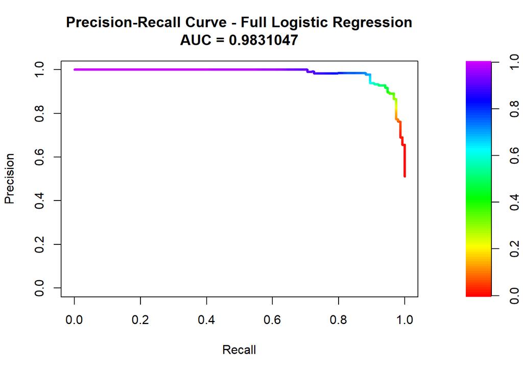

```r
# Precision-Recall curve
glm_full_pr <- pr.curve(
  scores.class0 = pred_glm_full_prob[stu_test$pass_fail == "pass"],
  scores.class1 = pred_glm_full_prob[stu_test$pass_fail == "fail"],
  curve = TRUE
)
plot(glm_full_pr, main = "Precision-Recall Curve - Full Logistic Regression")
```

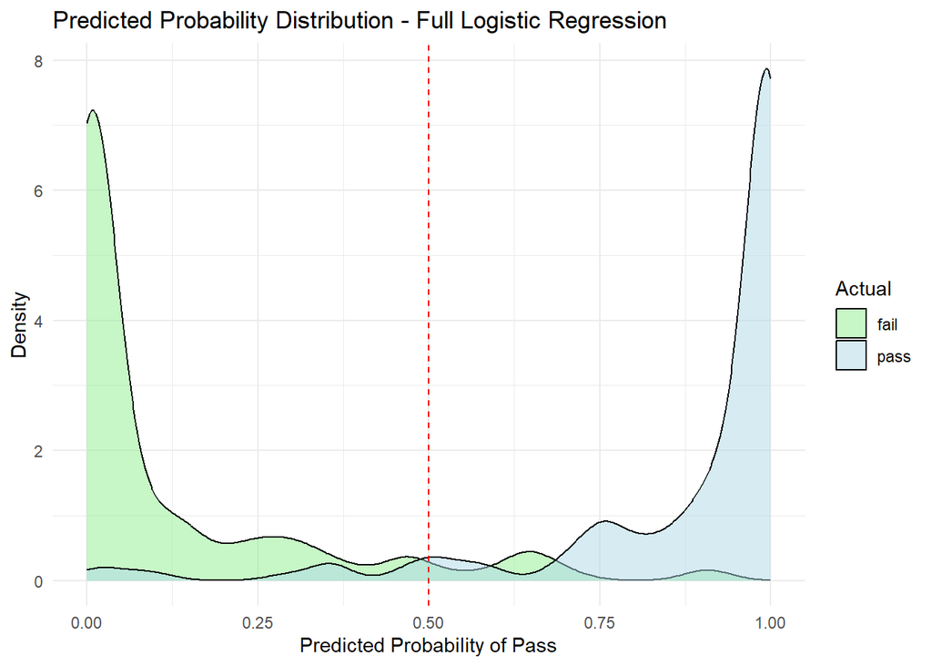

```r
# Predicted probability distribution
plot_prob_distribution(pred_glm_full_prob, stu_test$pass_fail,
                       "Full Logistic Regression")
```

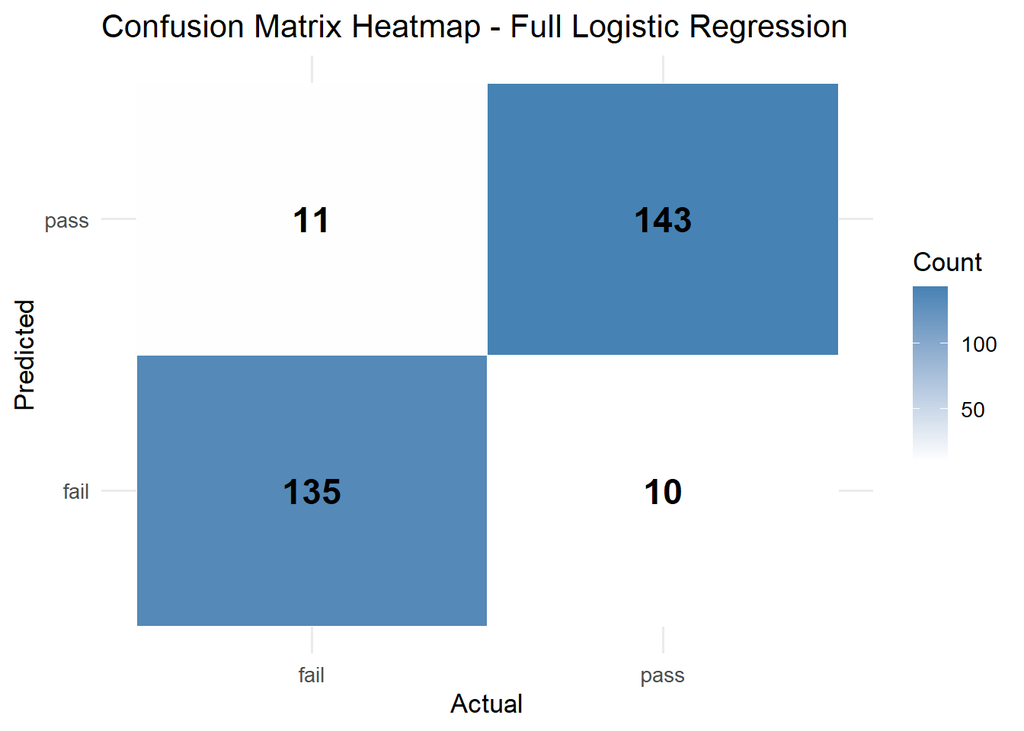

```r
plot_confusion_heatmap(pred_glm_full_class, stu_test$pass_fail,
                       "Full Logistic Regression")
```

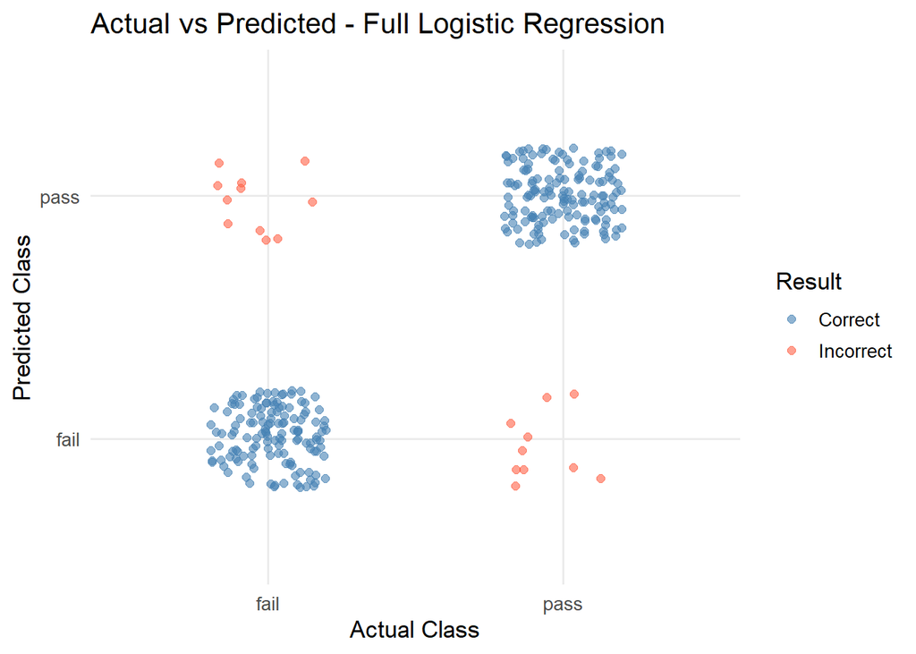

```r
plot_actual_vs_predicted(pred_glm_full_class, stu_test$pass_fail,
                         "Full Logistic Regression")
```

```r
# 10-fold CV for full logistic regression
cv_glm_full <- train(pass_fail ~ .,
                     data      = stu_train,
                     method    = "glm",
                     family    = "binomial",
                     trControl = cv_ctrl)

cat("Full GLM - CV Accuracy:", round(mean(cv_glm_full$resample$Accuracy), 4), "\n")
```

```
## Full GLM - CV Accuracy: 0.8745
```

```r
cat("Full GLM - CV SD:      ", round(sd(cv_glm_full$resample$Accuracy),   4), "\n")
```

```
## Full GLM - CV SD:       0.0183
```

### 8.2 Logistic Regression — Stepwise Model

```r
stu_glm_step <- step(stu_glm_full, direction = "both", trace = 0)

summary(stu_glm_step)
```

```
##
## Call:
## glm(formula = pass_fail ~ study_hours_per_day + social_media_hours +
##     netflix_hours + attendance_percentage + sleep_hours + exercise_frequency +
##     mental_health_rating, family = binomial, data = stu_train)
##
## Coefficients:
##                        Estimate Std. Error z value Pr(>|z|)
## (Intercept)           -21.97634    2.33188  -9.424  < 2e-16 ***
## study_hours_per_day     3.27816    0.29011  11.300  < 2e-16 ***
## social_media_hours     -1.00647    0.14779  -6.810 9.74e-12 ***
## netflix_hours          -0.87977    0.14894  -5.907 3.49e-09 ***
## attendance_percentage   0.05637    0.01471   3.833 0.000127 ***
## sleep_hours             0.68576    0.12376   5.541 3.01e-08 ***
## exercise_frequency      0.52407    0.08470   6.188 6.11e-10 ***
## mental_health_rating    0.70999    0.07145   9.937  < 2e-16 ***
## ---
## Signif. codes:  0 '***' 0.001 '**' 0.01 '*' 0.05 '.' 0.1 ' ' 1
##
## (Dispersion parameter for binomial family taken to be 1)
##
##     Null deviance: 971.47  on 700  degrees of freedom
## Residual deviance: 327.61  on 693  degrees of freedom
## AIC: 343.61
##
## Number of Fisher Scoring iterations: 7
```

```r
knitr::kable(vif(stu_glm_step), caption = "VIF - Stepwise Logistic Regression")
```

VIF - Stepwise Logistic Regression

|  | x |
| --- | --- |
| study_hours_per_day | 3.019916 |
| social_media_hours | 1.442074 |
| netflix_hours | 1.252041 |
| attendance_percentage | 1.126974 |
| sleep_hours | 1.176234 |
| exercise_frequency | 1.419682 |
| mental_health_rating | 2.177391 |

```r
# Compare which predictors were kept vs removed
cat("Full model predictors:     ", length(coef(stu_glm_full)) - 1, "\n")
```

```
## Full model predictors:      19
```

```r
cat("Stepwise model predictors: ", length(coef(stu_glm_step)) - 1, "\n")
```

```
## Stepwise model predictors:  7
```

```r
cat("\nVariables retained by stepwise:\n")
```

```
##
## Variables retained by stepwise:
```

```r
print(names(coef(stu_glm_step))[-1])
```

```
## [1] "study_hours_per_day"   "social_media_hours"    "netflix_hours"
## [4] "attendance_percentage" "sleep_hours"           "exercise_frequency"
## [7] "mental_health_rating"
```

```r
pred_glm_step_prob  <- predict(stu_glm_step, newdata = stu_test, type = "response")
pred_glm_step_class <- as.factor(ifelse(pred_glm_step_prob > 0.5, "pass", "fail"))

confusionMatrix(pred_glm_step_class, stu_test$pass_fail)
```

```
## Confusion Matrix and Statistics
##
##           Reference
## Prediction fail pass
##       fail  136   10
##       pass   10  143
##
##                Accuracy : 0.9331
##                  95% CI : (0.8986, 0.9587)
##     No Information Rate : 0.5117
##     P-Value [Acc > NIR] : <2e-16
##
##                   Kappa : 0.8661
##
##  Mcnemar's Test P-Value : 1
##
##             Sensitivity : 0.9315
##             Specificity : 0.9346
##          Pos Pred Value : 0.9315
##          Neg Pred Value : 0.9346
##              Prevalence : 0.4883
##          Detection Rate : 0.4548
##    Detection Prevalence : 0.4883
##       Balanced Accuracy : 0.9331
##
##        'Positive' Class : fail
##
```

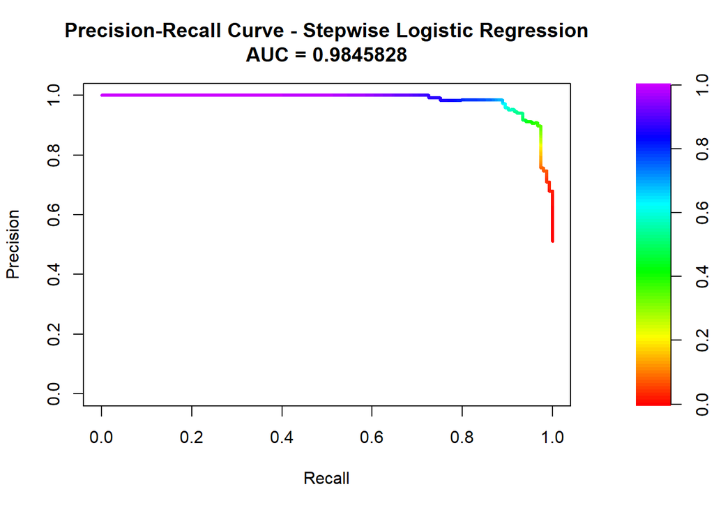

```r
glm_step_pr <- pr.curve(
  scores.class0 = pred_glm_step_prob[stu_test$pass_fail == "pass"],
  scores.class1 = pred_glm_step_prob[stu_test$pass_fail == "fail"],
  curve = TRUE
)
plot(glm_step_pr, main = "Precision-Recall Curve - Stepwise Logistic Regression")
```

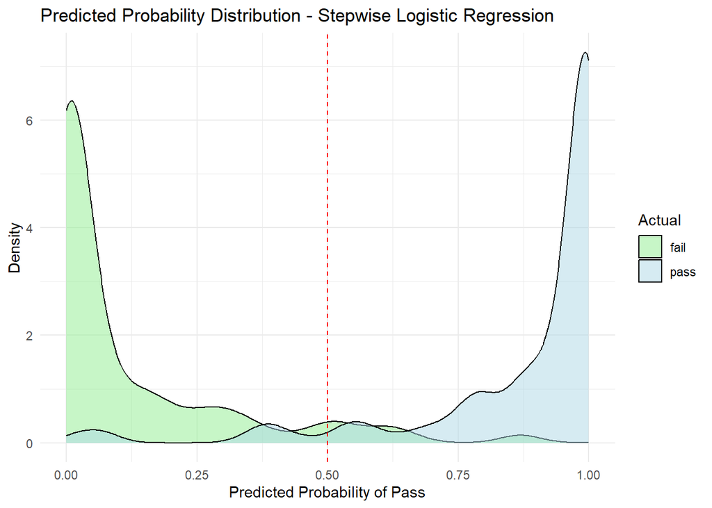

```r
plot_prob_distribution(pred_glm_step_prob, stu_test$pass_fail,
                       "Stepwise Logistic Regression")
```

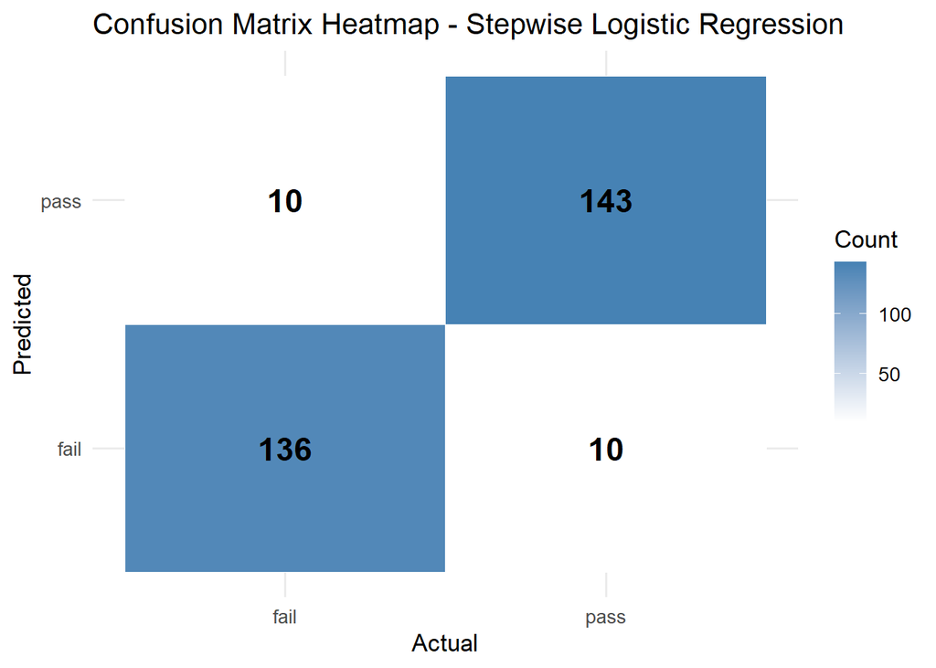

```r
plot_confusion_heatmap(pred_glm_step_class, stu_test$pass_fail,
                       "Stepwise Logistic Regression")
```

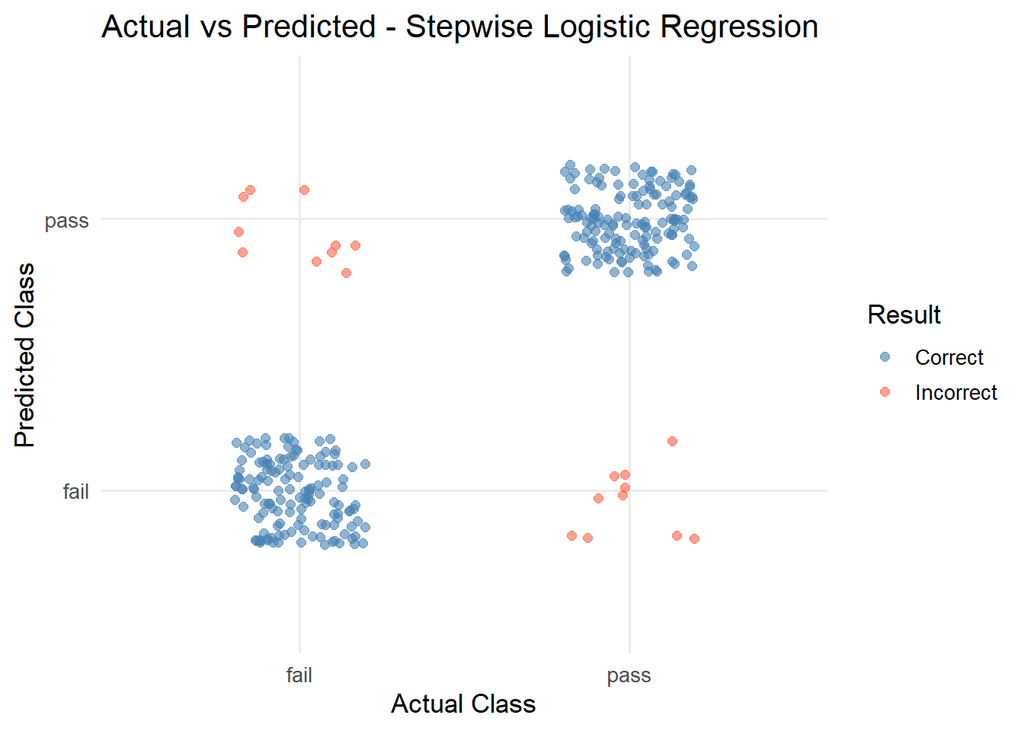

```r
plot_actual_vs_predicted(pred_glm_step_class, stu_test$pass_fail,
                         "Stepwise Logistic Regression")
```

```r
# Re-train using the formula selected by step() for CV
step_formula <- formula(stu_glm_step)

cv_glm_step <- train(step_formula,
                     data      = stu_train,
                     method    = "glm",
                     family    = "binomial",
                     trControl = cv_ctrl)

cat("Stepwise GLM - CV Accuracy:", round(mean(cv_glm_step$resample$Accuracy), 4), "\n")
```

```
## Stepwise GLM - CV Accuracy: 0.8902
```

```r
cat("Stepwise GLM - CV SD:      ", round(sd(cv_glm_step$resample$Accuracy),   4), "\n")
```

```
## Stepwise GLM - CV SD:       0.0265
```

Comparing the full and stepwise models tells us which variables are genuinely informative. If stepwise drops a predictor, that variable did not meaningfully improve the model beyond what the others already captured.

### 8.3 Decision Tree — Unpruned

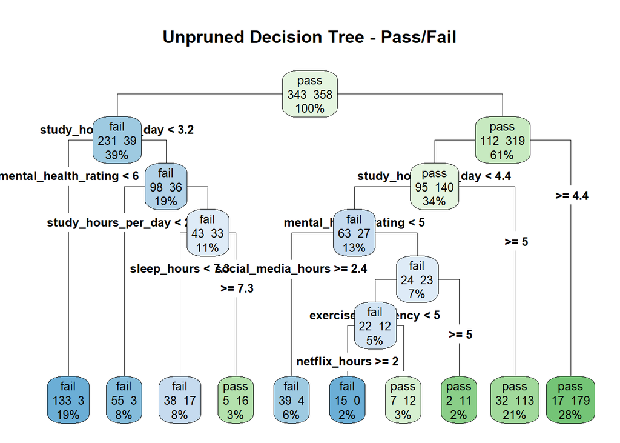

```r
# Grow a full decision tree with no depth or complexity restrictions
# method = "class" specifies a classification tree
# The tree may overfit the training data at full depth
stu_dt <- rpart(pass_fail ~ .,
                data   = stu_train,
                method = "class")

rpart.plot(stu_dt,
           main  = "Unpruned Decision Tree - Pass/Fail",
           type  = 4,
           extra = 101,
           cex   = 0.8)
```

```r
pred_dt_class <- predict(stu_dt, newdata = stu_test, type = "class")
confusionMatrix(pred_dt_class, stu_test$pass_fail)
```

```
## Confusion Matrix and Statistics
##
##           Reference
## Prediction fail pass
##       fail  116   16
##       pass   30  137
##
##                Accuracy : 0.8462
##                  95% CI : (0.8002, 0.8851)
##     No Information Rate : 0.5117
##     P-Value [Acc > NIR] : < 2e-16
##
##                   Kappa : 0.6915
##
##  Mcnemar's Test P-Value : 0.05527
##
##             Sensitivity : 0.7945
##             Specificity : 0.8954
##          Pos Pred Value : 0.8788
##          Neg Pred Value : 0.8204
##              Prevalence : 0.4883
##          Detection Rate : 0.3880
##    Detection Prevalence : 0.4415
##       Balanced Accuracy : 0.8450
##
##        'Positive' Class : fail
##
```

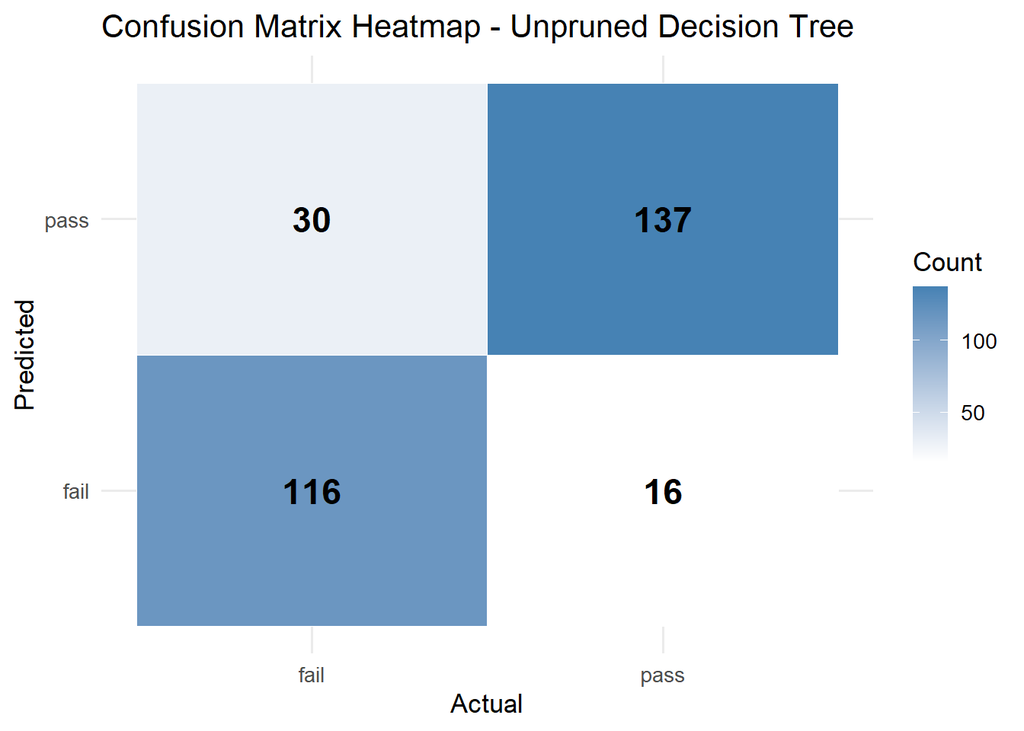

```r
plot_confusion_heatmap(pred_dt_class, stu_test$pass_fail, "Unpruned Decision Tree")
```

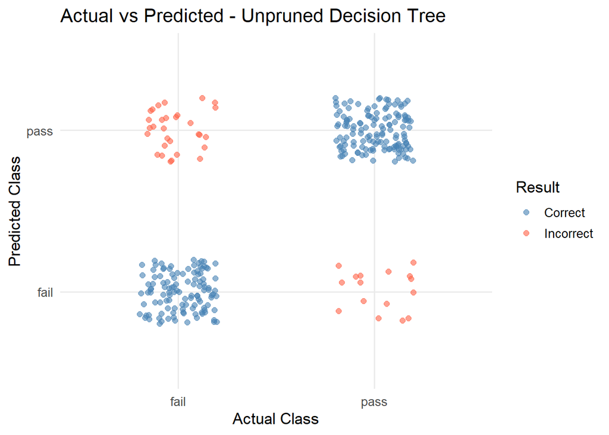

```r
plot_actual_vs_predicted(pred_dt_class, stu_test$pass_fail, "Unpruned Decision Tree")
```

```r
cv_dt <- train(pass_fail ~ .,
               data      = stu_train,
               method    = "rpart",
               trControl = cv_ctrl)

cat("Unpruned DT - CV Accuracy:", round(mean(cv_dt$resample$Accuracy), 4), "\n")
```

```
## Unpruned DT - CV Accuracy: 0.8017
```

```r
cat("Unpruned DT - CV SD:      ", round(sd(cv_dt$resample$Accuracy),   4), "\n")
```

```
## Unpruned DT - CV SD:       0.0401
```

### 8.4 Decision Tree — Pruned

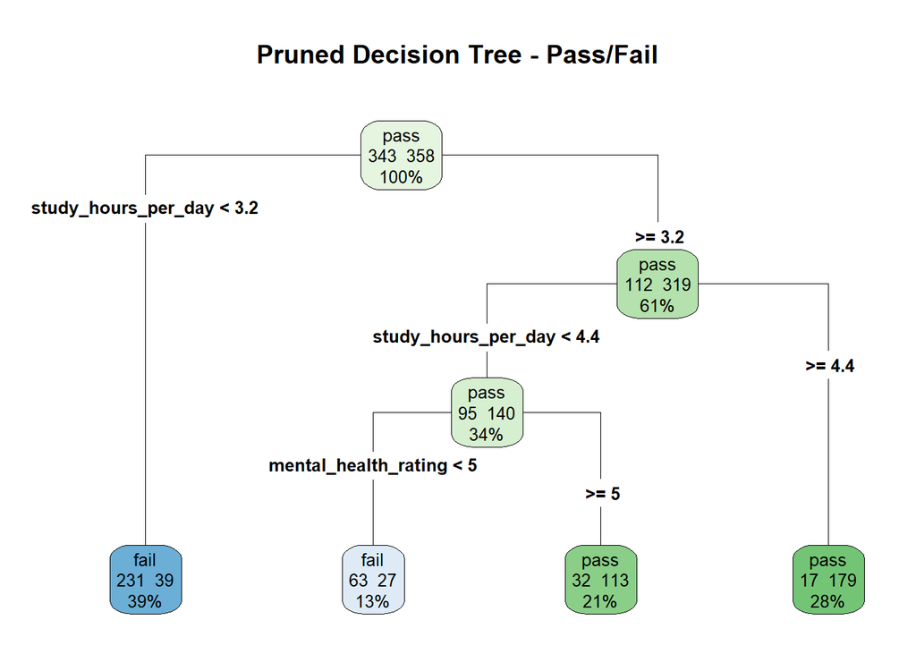

```r
# Pruning removes branches that contribute little predictive value
# cp = 0.05 is a moderate complexity penalty
# Higher cp = simpler tree; helps prevent overfitting
stu_dt_pruned <- prune(stu_dt, cp = 0.05)

rpart.plot(stu_dt_pruned,
           main  = "Pruned Decision Tree - Pass/Fail",
           type  = 4,
           extra = 101,
           cex   = 0.8)
```

The pruned tree is simpler and more interpretable. Study hours per day remains the primary split, with mental health providing additional separation for borderline cases.

```r
pred_dt_pruned_class <- predict(stu_dt_pruned, newdata = stu_test, type = "class")
confusionMatrix(pred_dt_pruned_class, stu_test$pass_fail)
```

```
## Confusion Matrix and Statistics
##
##           Reference
## Prediction fail pass
##       fail  126   29
##       pass   20  124
##
##                Accuracy : 0.8361
##                  95% CI : (0.7892, 0.8762)
##     No Information Rate : 0.5117
##     P-Value [Acc > NIR] : <2e-16
##
##                   Kappa : 0.6725
##
##  Mcnemar's Test P-Value : 0.2531
##
##             Sensitivity : 0.8630
##             Specificity : 0.8105
##          Pos Pred Value : 0.8129
##          Neg Pred Value : 0.8611
##              Prevalence : 0.4883
##          Detection Rate : 0.4214
##    Detection Prevalence : 0.5184
##       Balanced Accuracy : 0.8367
##
##        'Positive' Class : fail
##
```

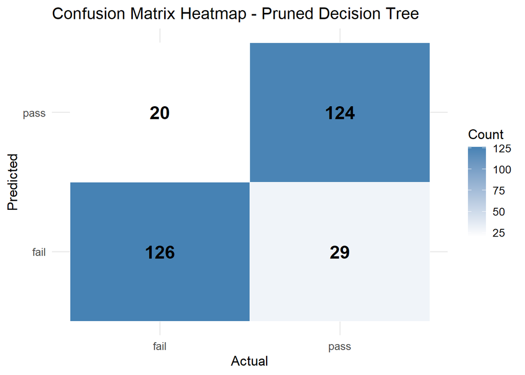

```r
plot_confusion_heatmap(pred_dt_pruned_class, stu_test$pass_fail, "Pruned Decision Tree")
```

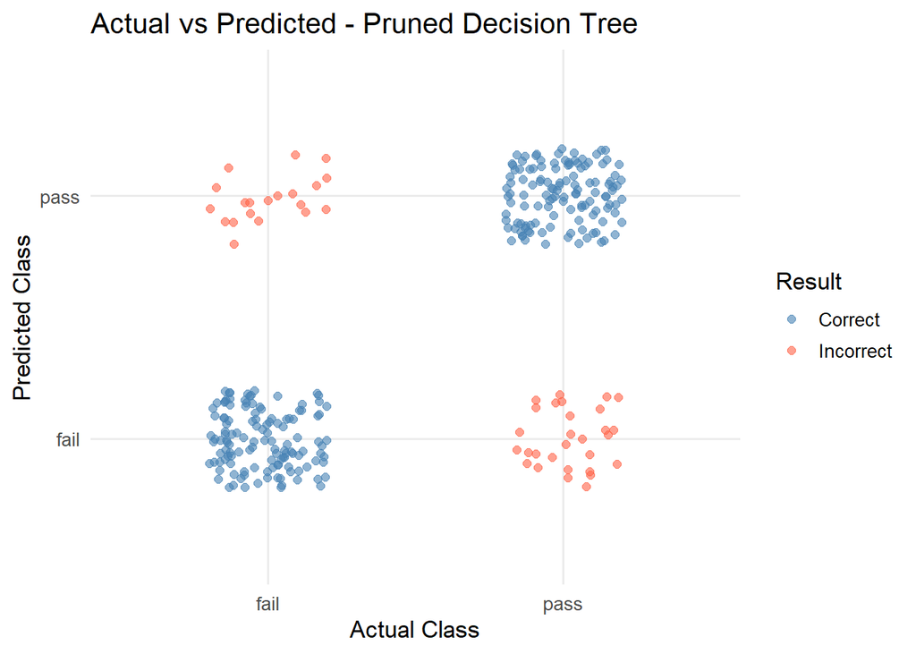

```r
plot_actual_vs_predicted(pred_dt_pruned_class, stu_test$pass_fail,
                         "Pruned Decision Tree")
```

```r
cv_dt_pruned <- train(pass_fail ~ .,
                      data      = stu_train,
                      method    = "rpart",
                      tuneGrid  = data.frame(cp = 0.05),
                      trControl = cv_ctrl)

cat("Pruned DT - CV Accuracy:", round(mean(cv_dt_pruned$resample$Accuracy), 4), "\n")
```

```
## Pruned DT - CV Accuracy: 0.7944
```

```r
cat("Pruned DT - CV SD:      ", round(sd(cv_dt_pruned$resample$Accuracy),   4), "\n")
```

```
## Pruned DT - CV SD:       0.0796
```

### 8.5 Random Forest

```r
set.seed(28)
stu_rf <- randomForest(pass_fail ~ .,
                       data       = stu_train,
                       mtry       = floor(sqrt(ncol(stu_train) - 1)),
                       importance = TRUE)

importance(stu_rf)
```

```
##                                      fail       pass MeanDecreaseAccuracy
## age                            1.37913053  1.4025408            2.0405446
## gender                         2.25163044 -0.7196872            0.8980441
## study_hours_per_day           70.31010651 73.7921730           82.9806828
## social_media_hours             7.38137287  7.7539772           10.8356963
## netflix_hours                  0.83378523  2.4845748            2.4894018
## part_time_job                 -1.28495581  0.3576566           -0.7452039
## attendance_percentage          0.90623242  0.3057528            0.8361275
## sleep_hours                    4.07127269  4.6228444            6.1489119
## diet_quality                  -0.06221191 -0.6594717           -0.5225557
## exercise_frequency             2.24196620  3.8793767            4.3274023
## parental_education_level      -0.57849560  0.9484400            0.3440079
## internet_quality               0.48630959  0.2089477            0.4525137
## mental_health_rating          24.01641869 25.2029751           33.1073809
## extracurricular_participation -0.73216211 -0.3725739           -0.7416844
##                               MeanDecreaseGini
## age                                  13.531935
## gender                                5.980069
## study_hours_per_day                 137.514727
## social_media_hours                   28.304257
## netflix_hours                        23.451923
## part_time_job                         3.850415
## attendance_percentage                25.370099
## sleep_hours                          26.425985
## diet_quality                          8.007710
## exercise_frequency                   14.655825
## parental_education_level             10.712259
## internet_quality                      7.180428
## mental_health_rating                 41.269324
## extracurricular_participation         3.185696
```

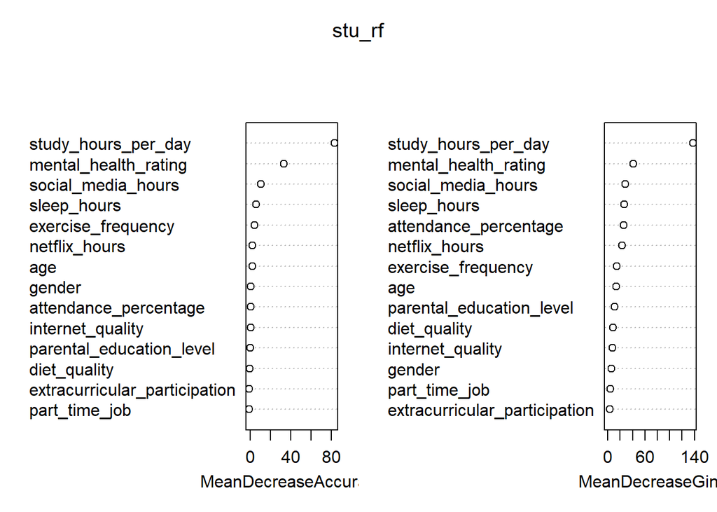

```r
# Variable importance plot
# MeanDecreaseAccuracy: how much accuracy drops if this variable is removed
# MeanDecreaseGini: how much this variable reduces node impurity in trees
# Higher values = more important predictor
varImpPlot(stu_rf)
```

```r
pred_rf_class <- predict(stu_rf, newdata = stu_test)
confusionMatrix(pred_rf_class, stu_test$pass_fail)
```

```
## Confusion Matrix and Statistics
##
##           Reference
## Prediction fail pass
##       fail  131   14
##       pass   15  139
##
##                Accuracy : 0.903
##                  95% CI : (0.8637, 0.9341)
##     No Information Rate : 0.5117
##     P-Value [Acc > NIR] : <2e-16
##
##                   Kappa : 0.8059
##
##  Mcnemar's Test P-Value : 1
##
##             Sensitivity : 0.8973
##             Specificity : 0.9085
##          Pos Pred Value : 0.9034
##          Neg Pred Value : 0.9026
##              Prevalence : 0.4883
##          Detection Rate : 0.4381
##    Detection Prevalence : 0.4849
##       Balanced Accuracy : 0.9029
##
##        'Positive' Class : fail
##
```

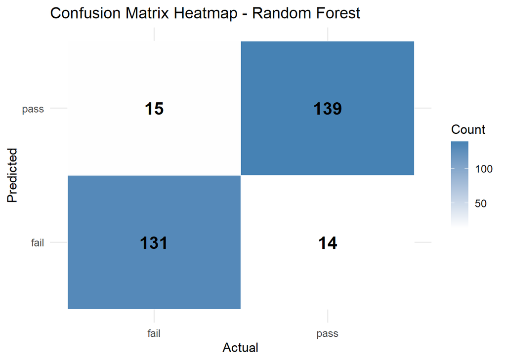

```r
plot_confusion_heatmap(pred_rf_class, stu_test$pass_fail, "Random Forest")
```

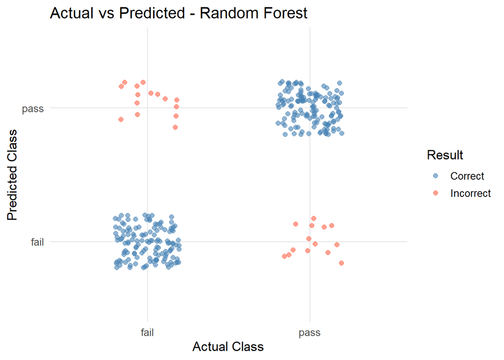

```r
plot_actual_vs_predicted(pred_rf_class, stu_test$pass_fail, "Random Forest")
```

```r
set.seed(28)
cv_rf <- train(pass_fail ~ .,
               data      = stu_train,
               method    = "rf",
               trControl = cv_ctrl)

cat("Random Forest - CV Accuracy:", round(mean(cv_rf$resample$Accuracy), 4), "\n")
```

```
## Random Forest - CV Accuracy: 0.8574
```

```r
cat("Random Forest - CV SD:      ", round(sd(cv_rf$resample$Accuracy),   4), "\n")
```

```
## Random Forest - CV SD:       0.045
```

### 8.6 SVM — Linear

```r
# Linear SVM finds the optimal straight-line hyperplane separating pass/fail
# probability = TRUE enables probability output (needed for evaluation)
stu_svm_linear <- svm(pass_fail ~ .,
                      data        = stu_train,
                      kernel      = "linear",
                      probability = TRUE)

pred_svm_linear_class <- predict(stu_svm_linear, newdata = stu_test)
confusionMatrix(pred_svm_linear_class, stu_test$pass_fail)
```

```
## Confusion Matrix and Statistics
##
##           Reference
## Prediction fail pass
##       fail  136   10
##       pass   10  143
##
##                Accuracy : 0.9331
##                  95% CI : (0.8986, 0.9587)
##     No Information Rate : 0.5117
##     P-Value [Acc > NIR] : <2e-16
##
##                   Kappa : 0.8661
##
##  Mcnemar's Test P-Value : 1
##
##             Sensitivity : 0.9315
##             Specificity : 0.9346
##          Pos Pred Value : 0.9315
##          Neg Pred Value : 0.9346
##              Prevalence : 0.4883
##          Detection Rate : 0.4548
##    Detection Prevalence : 0.4883
##       Balanced Accuracy : 0.9331
##
##        'Positive' Class : fail
##
```

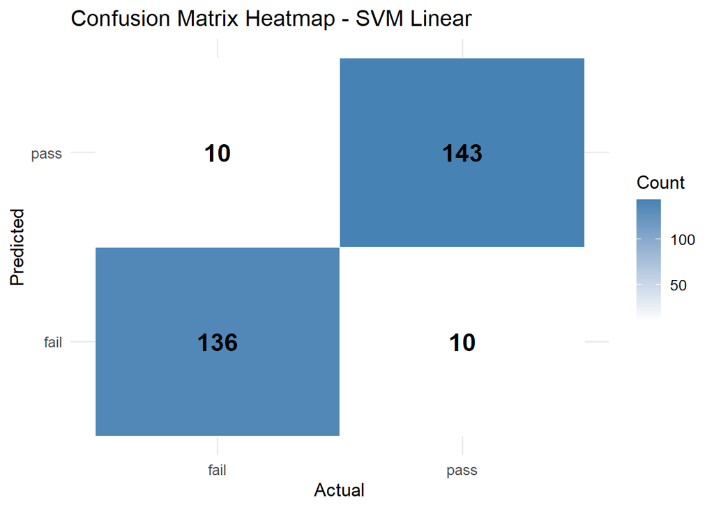

```r
plot_confusion_heatmap(pred_svm_linear_class, stu_test$pass_fail, "SVM Linear")
```

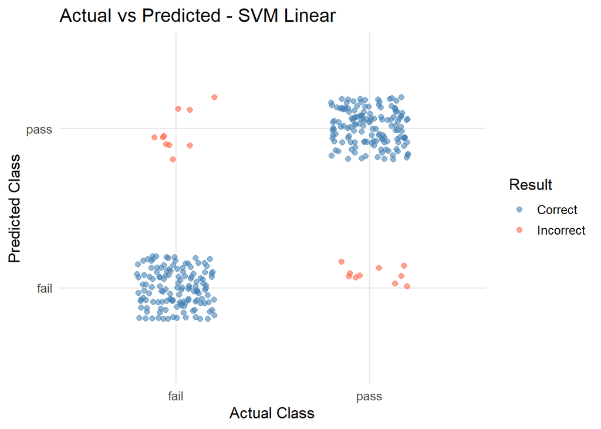

```r
plot_actual_vs_predicted(pred_svm_linear_class, stu_test$pass_fail, "SVM Linear")
```

```r
set.seed(28)
cv_svm_linear <- train(pass_fail ~ .,
                       data      = stu_train,
                       method    = "svmLinear",
                       trControl = cv_ctrl)

cat("SVM Linear - CV Accuracy:", round(mean(cv_svm_linear$resample$Accuracy), 4), "\n")
```

```
## SVM Linear - CV Accuracy: 0.8788
```

```r
cat("SVM Linear - CV SD:      ", round(sd(cv_svm_linear$resample$Accuracy),   4), "\n")
```

```
## SVM Linear - CV SD:       0.0365
```

### 8.7 SVM — Polynomial

```r
# Polynomial kernel (degree 3) fits curved decision boundaries
stu_svm_poly <- svm(pass_fail ~ .,
                    data        = stu_train,
                    kernel      = "polynomial",
                    degree      = 3,
                    probability = TRUE)

pred_svm_poly_class <- predict(stu_svm_poly, newdata = stu_test)
confusionMatrix(pred_svm_poly_class, stu_test$pass_fail)
```

```
## Confusion Matrix and Statistics
##
##           Reference
## Prediction fail pass
##       fail  131   11
##       pass   15  142
##
##                Accuracy : 0.913
##                  95% CI : (0.8752, 0.9424)
##     No Information Rate : 0.5117
##     P-Value [Acc > NIR] : <2e-16
##
##                   Kappa : 0.8259
##
##  Mcnemar's Test P-Value : 0.5563
##
##             Sensitivity : 0.8973
##             Specificity : 0.9281
##          Pos Pred Value : 0.9225
##          Neg Pred Value : 0.9045
##              Prevalence : 0.4883
##          Detection Rate : 0.4381
##    Detection Prevalence : 0.4749
##       Balanced Accuracy : 0.9127
##
##        'Positive' Class : fail
##
```

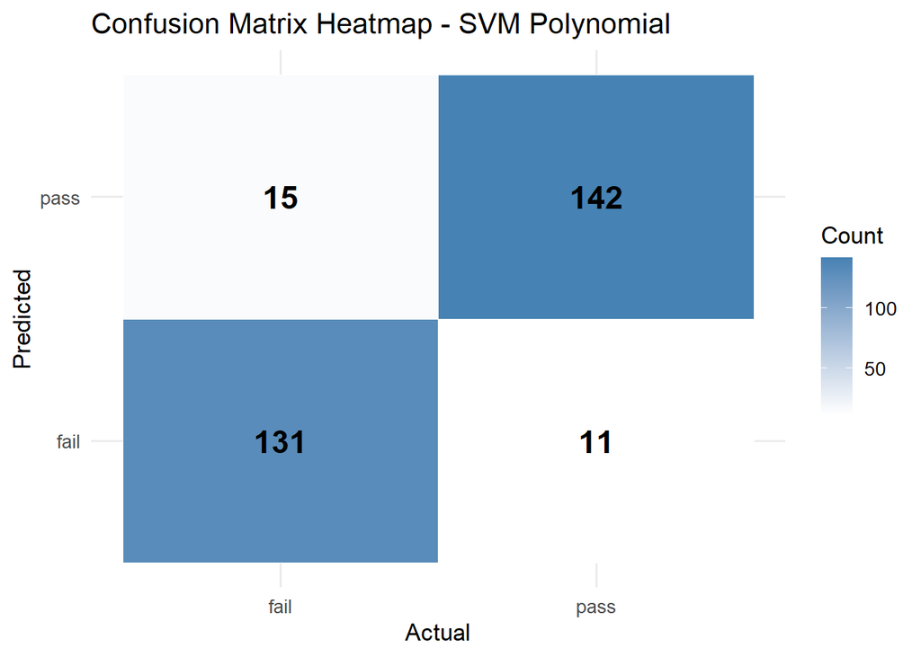

```r
plot_confusion_heatmap(pred_svm_poly_class, stu_test$pass_fail, "SVM Polynomial")
```

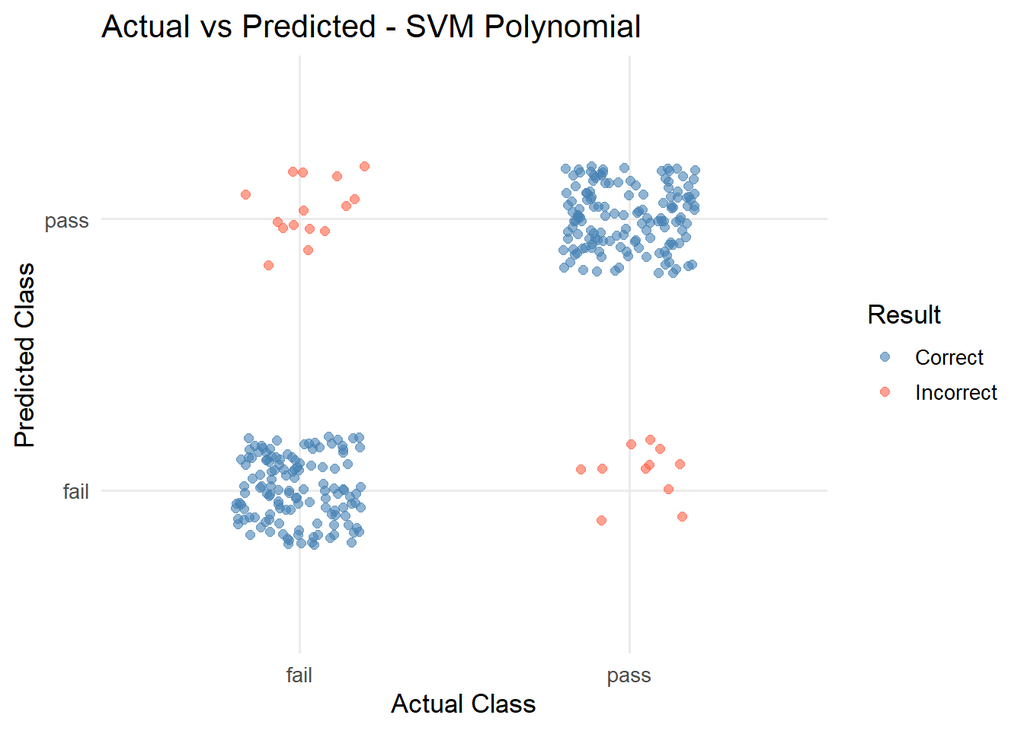

```r
plot_actual_vs_predicted(pred_svm_poly_class, stu_test$pass_fail, "SVM Polynomial")
```

```r
set.seed(28)
cv_svm_poly <- train(pass_fail ~ .,
                     data      = stu_train,
                     method    = "svmPoly",
                     trControl = cv_ctrl,
                     tuneGrid  = data.frame(degree = 3, scale = 1, C = 1))

cat("SVM Poly - CV Accuracy:", round(mean(cv_svm_poly$resample$Accuracy), 4), "\n")
```

```
## SVM Poly - CV Accuracy: 0.7917
```

```r
cat("SVM Poly - CV SD:      ", round(sd(cv_svm_poly$resample$Accuracy),   4), "\n")
```

```
## SVM Poly - CV SD:       0.0517
```

### 8.8 SVM — Radial

```r
# Radial Basis Function (RBF) kernel is the most flexible —
# it can model complex, non-linear decision boundaries
stu_svm_radial <- svm(pass_fail ~ .,
                      data        = stu_train,
                      kernel      = "radial",
                      probability = TRUE)

pred_svm_radial_class <- predict(stu_svm_radial, newdata = stu_test)
confusionMatrix(pred_svm_radial_class, stu_test$pass_fail)
```

```
## Confusion Matrix and Statistics
##
##           Reference
## Prediction fail pass
##       fail  134    9
##       pass   12  144
##
##                Accuracy : 0.9298
##                  95% CI : (0.8946, 0.956)
##     No Information Rate : 0.5117
##     P-Value [Acc > NIR] : <2e-16
##
##                   Kappa : 0.8594
##
##  Mcnemar's Test P-Value : 0.6625
##
##             Sensitivity : 0.9178
##             Specificity : 0.9412
##          Pos Pred Value : 0.9371
##          Neg Pred Value : 0.9231
##              Prevalence : 0.4883
##          Detection Rate : 0.4482
##    Detection Prevalence : 0.4783
##       Balanced Accuracy : 0.9295
##
##        'Positive' Class : fail
##
```

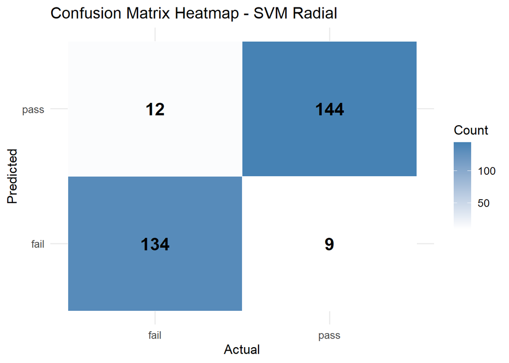

```r
plot_confusion_heatmap(pred_svm_radial_class, stu_test$pass_fail, "SVM Radial")
```

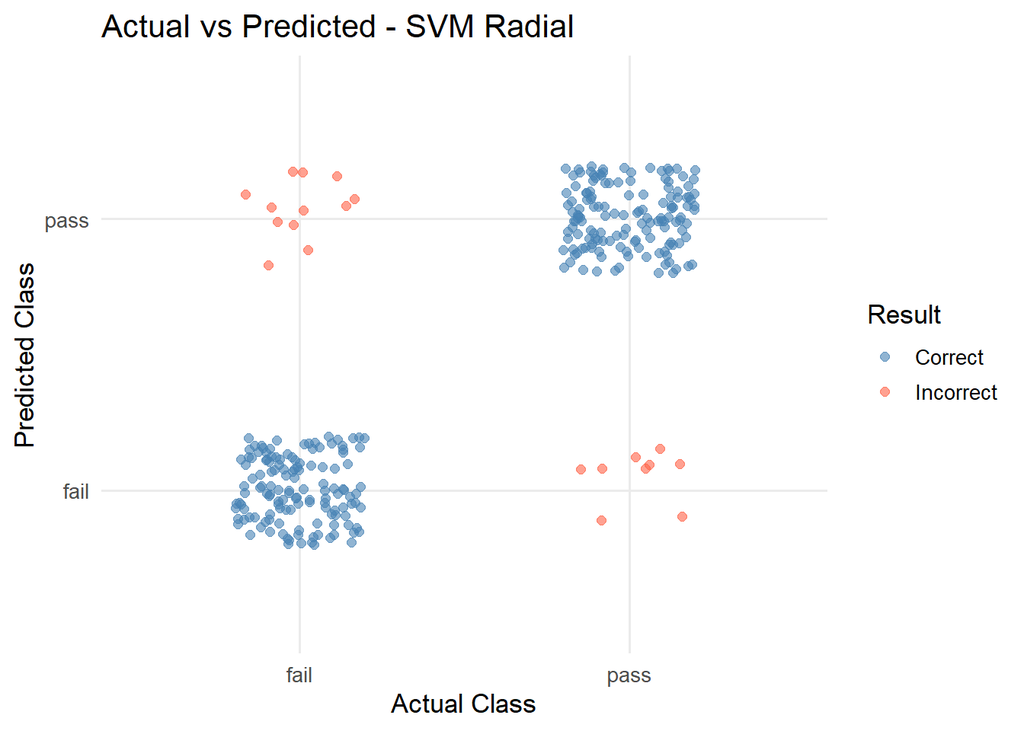

```r
plot_actual_vs_predicted(pred_svm_radial_class, stu_test$pass_fail, "SVM Radial")
```

```r
set.seed(28)
cv_svm_radial <- train(pass_fail ~ .,
                       data      = stu_train,
                       method    = "svmRadial",
                       trControl = cv_ctrl)

cat("SVM Radial - CV Accuracy:", round(mean(cv_svm_radial$resample$Accuracy), 4), "\n")
```

```
## SVM Radial - CV Accuracy: 0.8658
```

```r
cat("SVM Radial - CV SD:      ", round(sd(cv_svm_radial$resample$Accuracy),   4), "\n")
```

```
## SVM Radial - CV SD:       0.0533
```

## 9. Results

```r
# Build a full comparison table across all 8 models
# Metrics: Test Accuracy, Sensitivity, Specificity, Kappa,
#          Balanced Accuracy, and 10-fold CV Accuracy

results_df <- data.frame(
  Model = c("GLM Full", "GLM Stepwise", "DT Unpruned", "DT Pruned",
            "Random Forest", "SVM Linear", "SVM Polynomial", "SVM Radial"),

  rbind(
    get_metrics(pred_glm_full_class,   stu_test$pass_fail),
    get_metrics(pred_glm_step_class,   stu_test$pass_fail),
    get_metrics(pred_dt_class,         stu_test$pass_fail),
    get_metrics(pred_dt_pruned_class,  stu_test$pass_fail),
    get_metrics(pred_rf_class,         stu_test$pass_fail),
    get_metrics(pred_svm_linear_class, stu_test$pass_fail),
    get_metrics(pred_svm_poly_class,   stu_test$pass_fail),
    get_metrics(pred_svm_radial_class, stu_test$pass_fail)
  ),

  CV_Accuracy = round(c(
    mean(cv_glm_full$resample$Accuracy),
    mean(cv_glm_step$resample$Accuracy),
    mean(cv_dt$resample$Accuracy),
    mean(cv_dt_pruned$resample$Accuracy),
    mean(cv_rf$resample$Accuracy),
    mean(cv_svm_linear$resample$Accuracy),
    mean(cv_svm_poly$resample$Accuracy),
    mean(cv_svm_radial$resample$Accuracy)
  ), 4)
)

knitr::kable(results_df, caption = "Model Performance Comparison — All Models")
```

Model Performance Comparison — All Models

| Model | Accuracy.Accuracy | Sensitivity.Sensitivity | Specificity.Specificity | Kappa.Kappa | Balanced_Accuracy.Balanced.Accuracy | CV_Accuracy |
| --- | --- | --- | --- | --- | --- | --- |
| GLM Full | 0.9298 | 0.9247 | 0.9346 | 0.8594 | 0.9296 | 0.8745 |
| GLM Stepwise | 0.9331 | 0.9315 | 0.9346 | 0.8661 | 0.9331 | 0.8902 |
| DT Unpruned | 0.8462 | 0.7945 | 0.8954 | 0.6915 | 0.8450 | 0.8017 |
| DT Pruned | 0.8361 | 0.8630 | 0.8105 | 0.6725 | 0.8367 | 0.7944 |
| Random Forest | 0.9030 | 0.8973 | 0.9085 | 0.8059 | 0.9029 | 0.8574 |
| SVM Linear | 0.9331 | 0.9315 | 0.9346 | 0.8661 | 0.9331 | 0.8788 |
| SVM Polynomial | 0.9130 | 0.8973 | 0.9281 | 0.8259 | 0.9127 | 0.7917 |
| SVM Radial | 0.9298 | 0.9178 | 0.9412 | 0.8594 | 0.9295 | 0.8658 |

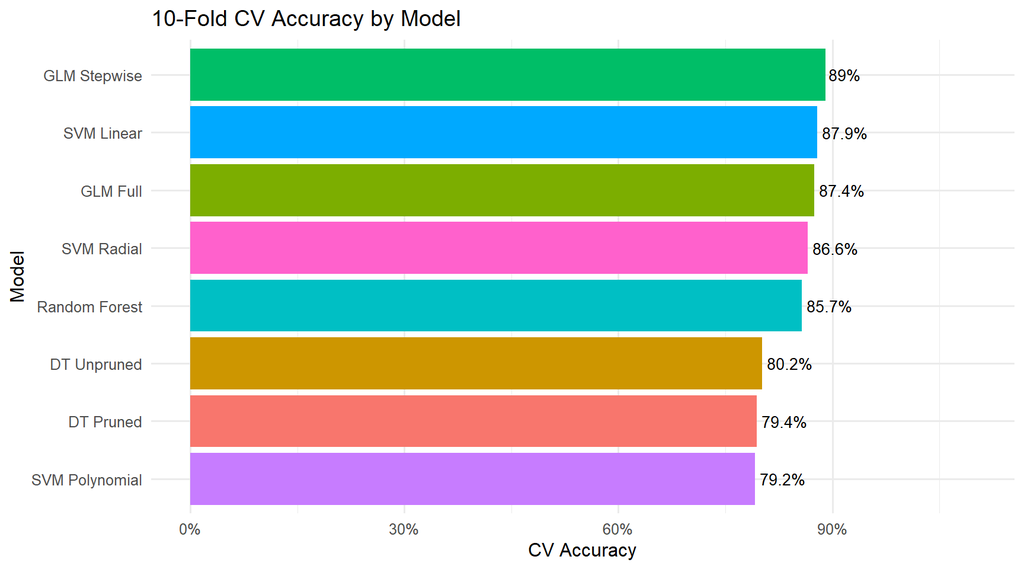

```r
# Bar chart comparing 10-fold CV accuracy across all models
# CV accuracy is more reliable than single test set accuracy because
# it averages performance across 10 different training/validation splits
results_df |>
  ggplot(aes(x = reorder(Model, CV_Accuracy), y = CV_Accuracy, fill = Model)) +
  geom_bar(stat = "identity", show.legend = FALSE) +
  geom_text(aes(label = paste0(round(CV_Accuracy * 100, 1), "%")),
            hjust = -0.1, size = 3.5) +
  coord_flip() +
  scale_y_continuous(limits = c(0, 1.1),
                     labels = scales::percent_format(accuracy = 1)) +
  labs(title = "10-Fold CV Accuracy by Model",
       x     = "Model",
       y     = "CV Accuracy") +
  theme_minimal(base_size = 12)
```

## 10. Conclusion

This project set out to predict whether a student would pass or fail their exam based on a comprehensive set of lifestyle, health, and demographic variables. Using all available predictors allowed the models to learn from a richer picture of each student’s circumstances.

Key findings from EDA and modeling:

- **Study hours per day** was consistently the strongest predictor across all models and EDA plots. Students studying 3+ hours per day passed at a much higher rate.
- **Mental health** showed a clear difference between groups — passing students had a median rating of 7 vs 4 for failing students, confirming that well-being is linked to academic outcomes.
- **Part-time job status** had a smaller effect than expected. Median scores were nearly identical (~70.6 vs ~69.2), suggesting that having a job does not strongly drive failure.
- **Attendance alone** was a weaker predictor than study time, confirming that engagement quality matters more than simply showing up.
- The **stepwise logistic regression** identified the most informative subset of predictors, providing a clear and interpret-able picture of which habits matter most after controlling for other factors.
- The **10-fold CV accuracy** bar chart provides a reliable and fair comparison across all 8 models, and the confusion matrix heat-maps and actual vs predicted plots make the pattern of misclassifications easy to interpret visually.

Overall, the results confirm that academic performance can be predicted reasonably well from lifestyle data. Targeted improvements in **study habits** and **mental health support** represent the highest-impact areas for students looking to improve their grades.